# Final pakchoi diversity analyses

Eddy Dowle

2025-09-22

## Pak choi

Diversity analyses, and summary plots

```r
#corrected dataset with raw counts
data<-read_excel('C:/Users/hrlexd/Dropbox/PlantAndFood (1)/B4BI/Pakchoi/Copy of Pak choi pollinators raw visits Brad correctedupdatedEddy.xlsx',sheet='Pak choi raw visits')

#filter out things that are 2018 in Boundary age column
data<-data %>% filter(`Boundary age`!=2018)


brads_col_2<-read_excel('C:/Users/hrlexd/Dropbox/PlantAndFood (1)/B4BI/Pakchoi/Eddy Pie chart short.xlsx',sheet='Colours')
#tidy up some names etc
data$Boundary_descriptor<-gsub('one year old','One year old',data$Boundary_descriptor)
data$Boundary_descriptor<-gsub('two year old','Two year old',data$Boundary_descriptor)
data$Boundary_descriptor<-gsub('three year old','Three year old',data$Boundary_descriptor)
data$Boundary_descriptor<-gsub('Bare_fence','On-farm bare fence',data$Boundary_descriptor)
data$Boundary_descriptor<-gsub('Control_farm','Off-farm bare fence',data$Boundary_descriptor)

#summarising counts to clean up dataset etc for box plots
data_box<-data %>% select(-`Broad Insect category`,-Origin,-`Boundary age`,-`Sum of Insect_Count`,-`Flower count`) %>% group_by(`Farm type`,Farm_name,Season,Boundary_descriptor,`Insect key number`,`New Inseck key name`) %>% summarise(`Sum of Insects/100 flowers`=sum(`Sum of Insects/100 flowers`) )
```

```
## 'Boundary_descriptor', 'Insect key number'. You can override using the
```

```r
#counts per for below graph of abundance estimate per site
data_per<-data_box%>% mutate(Boundary_year=paste0(Boundary_descriptor,'_',Season)) %>% select(-`Insect key number`,-Boundary_descriptor,-Season) %>% group_by(`Farm type`,Farm_name,Boundary_year,`New Inseck key name`) %>% summarise(total_count=sum(`Sum of Insects/100 flowers`)) %>% ungroup() %>% group_by(`Farm type`,Farm_name,Boundary_year) %>% mutate(per=100*total_count/sum(total_count)) %>% ungroup()
```

```
## number`
## You can override using the `.groups` argument.
```

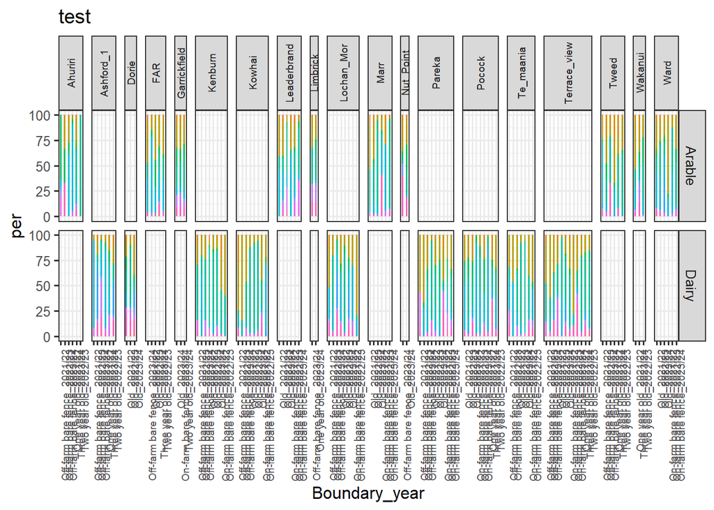

```r
data_per %>%   ggplot(aes(x = Boundary_year, y = per, fill = `New Inseck key name`)) +
  geom_bar(position='stack',stat='identity',width=0.4) +
  facet_grid(`Farm type`~Farm_name, scales = "free", space = "free") +
  theme_bw(base_size = 12) +
  theme(strip.text.x = element_text(angle = 90,size=7),axis.text.x = element_text(angle = 90,size=7,hjust=1))+
  ggtitle(paste('test'))+
 theme(legend.position="none")
```

```r
mydf<- data_box %>% mutate(Boundary_year=paste0(Boundary_descriptor,'_',Season))

#setting up for brads colour scheme
#relevel to brads order
brads_col_2$`New Inseck key name` <- factor(brads_col_2$`New Inseck key name`, levels=brads_col_2$`New Inseck key name`[order(brads_col_2$`Insect key number`)], ordered=TRUE)

#relevel to brads order
mydf$`New Inseck key name` <- forcats::fct_relevel(mydf$`New Inseck key name` ,levels(brads_col_2$`New Inseck key name`))
```

## Diversity statistics

Bar charts to view diversity over different groups

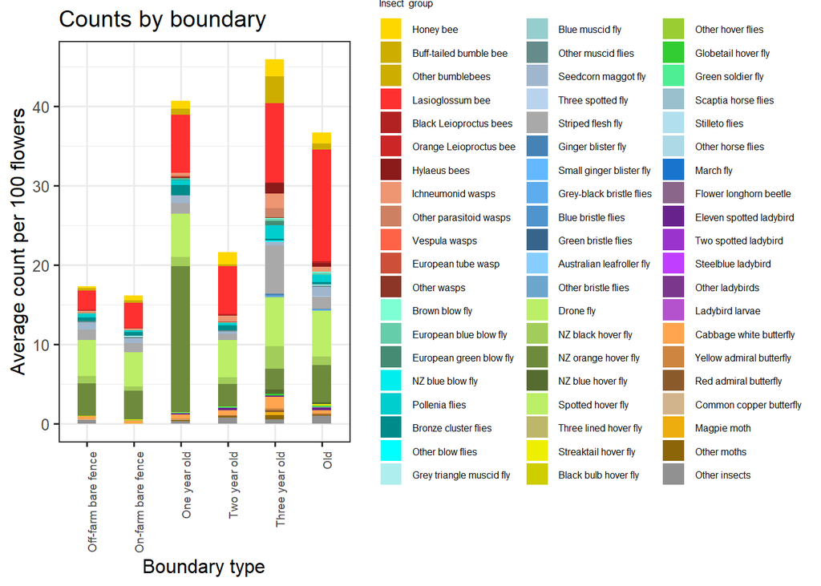

```r
##bar chart raw abundances .....
#cant just be raw count
#needs to be average by sampling number

mydf_byboundary_farm_count<-mydf %>% select(-`Insect key number`,-`Farm type`,-Boundary_year) %>% mutate(unique_ob=paste(Boundary_descriptor,Farm_name,Season)) %>% select(-Farm_name,-Season) %>% group_by(Boundary_descriptor,`New Inseck key name`) %>% summarise(count_farms_perobs=sum(`Sum of Insects/100 flowers`)/n_distinct(unique_ob))
mydf_byboundary_farm_count$Boundary_descriptor <- factor(mydf_byboundary_farm_count$Boundary_descriptor,levels=c('Off-farm bare fence','On-farm bare fence','One year old','Two year old','Three year old','Old'),ordered = T)

mydf_byboundary_farm_count %>%   ggplot(aes(x = Boundary_descriptor, y = count_farms_perobs, fill = `New Inseck key name`)) +
  geom_bar(position='stack',stat='identity',width=0.4) +
  # facet_grid(`Farm type`~Farm_name, scales = "free", space = "free") +
  theme_bw(base_size = 12) +
  theme(strip.text.x = element_text(angle = 90,size=7),axis.text.x = element_text(angle = 90,size=7,hjust=1))+
  scale_fill_manual(values=with(brads_col_2,setNames(Brad_colours,`New Inseck key name`)))+
  ggtitle(paste('Counts by boundary'))+ylab('Average count per 100 flowers')+xlab('Boundary type')+
  labs(fill = "Insect  group")+
  theme(
    legend.text = element_text(size = 6),
    legend.title = element_text(size = 6),
    legend.key.size = unit(1,"line"))
```

```r
#bar chart relative abundances % bare fence, control year 1, year 2 year3 and old
mydf_byboundary<-mydf%>% select(-`Insect key number`,-Season,-`Farm type`,-Farm_name,-Boundary_year) %>% group_by(Boundary_descriptor,`New Inseck key name`) %>% summarise(total_count=sum(`Sum of Insects/100 flowers`)) %>% ungroup() %>% group_by(Boundary_descriptor) %>% mutate(per=100*total_count/sum(total_count)) %>% ungroup()
```

```
## key number`
```

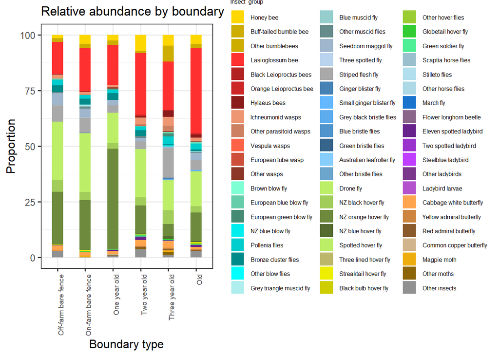

```r
#recolour and tidy
mydf_byboundary$Boundary_descriptor <- factor(mydf_byboundary$Boundary_descriptor,levels=c('Off-farm bare fence','On-farm bare fence','One year old','Two year old','Three year old','Old'),ordered = T)

mydf_byboundary %>%   ggplot(aes(x = Boundary_descriptor, y = per, fill = `New Inseck key name`)) +
  geom_bar(position='stack',stat='identity',width=0.4) +
  # facet_grid(`Farm type`~Farm_name, scales = "free", space = "free") +
  theme_bw(base_size = 12) +
  theme(strip.text.x = element_text(angle = 90,size=7),axis.text.x = element_text(angle = 90,size=7,hjust=1),plot.title = element_text(size = 13))+
  scale_fill_manual(values=with(brads_col_2,setNames(Brad_colours,`New Inseck key name`)))+
  ggtitle(paste('Relative abundance by boundary'))+ylab('Proportion')+xlab('Boundary type')+
  labs(fill = "Insect  group")+
  theme(
    legend.text = element_text(size = 6),
    legend.title = element_text(size = 6),
    legend.key.size = unit(1,"line"))
```

## Bar charts split by season

Alpha diversity (below) suggests there might be a role of season, so just splitting that out here. Season makes sense as the second year had a lot less counts than the first.

```r
#Adding in season
##bar chart raw abundances .....
#cant just be raw count
#needs to be average by sampling number

mydf_byboundary_farm_count_yr<-mydf %>% select(-`Insect key number`,-`Farm type`,-Boundary_descriptor,-Season) %>% mutate(unique_ob=paste(Boundary_year,Farm_name)) %>% select(-Farm_name) %>% group_by(Boundary_year,`New Inseck key name`) %>% summarise(count_farms_perobs=sum(`Sum of Insects/100 flowers`)/n_distinct(unique_ob))
```

```
## `Boundary_descriptor`, `Insect key number`
```

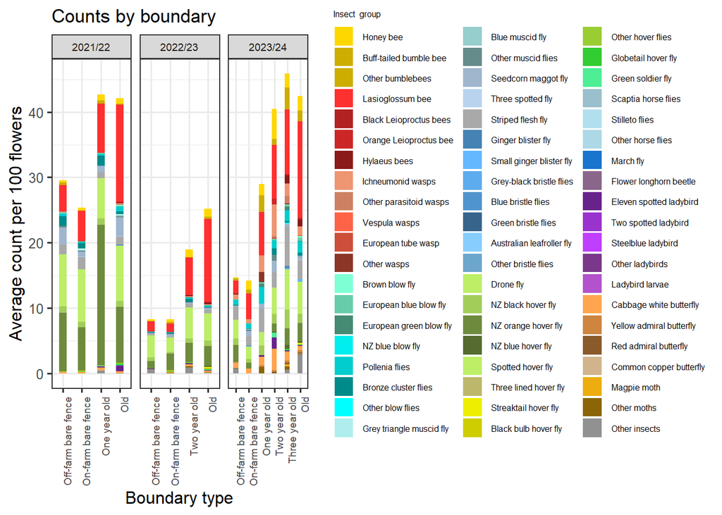

```r
mydf_byboundary_farm_count_yr<-mydf_byboundary_farm_count_yr %>% separate_wider_delim(Boundary_year,'_',names=c("Boundary_descriptor","Season"))

mydf_byboundary_farm_count_yr$Boundary_descriptor <- factor(mydf_byboundary_farm_count_yr$Boundary_descriptor,levels=c('Off-farm bare fence','On-farm bare fence','One year old','Two year old','Three year old','Old'),ordered = T)

mydf_byboundary_farm_count_yr %>%   ggplot(aes(x = Boundary_descriptor, y = count_farms_perobs, fill = `New Inseck key name`)) +
  geom_bar(position='stack',stat='identity',width=0.4) +
  facet_grid(~Season, scales = "free") +
  theme_bw(base_size = 12) +
  theme(strip.text.x = element_text(angle = 0,size=7),axis.text.x = element_text(angle = 90,size=7,hjust=1),plot.title = element_text(size = 13))+
  scale_fill_manual(values=with(brads_col_2,setNames(Brad_colours,`New Inseck key name`)))+
  ggtitle(paste('Counts by boundary'))+ylab('Average count per 100 flowers')+xlab('Boundary type')+
  labs(fill = "Insect  group")+
  theme(
    legend.text = element_text(size = 6),
    legend.title = element_text(size = 6),
    legend.key.size = unit(1,"line"))
```

```r
#adding in season
#bar chart relative abundances % bare fence, control year 1, year 2 year3 and old

mydf_byboundary_yr<-mydf%>% select(-`Insect key number`,-Season,-`Farm type`,-Farm_name,-Boundary_descriptor) %>% group_by(Boundary_year,`New Inseck key name`) %>% summarise(total_count=sum(`Sum of Insects/100 flowers`)) %>% ungroup() %>% group_by(Boundary_year) %>% mutate(per=100*total_count/sum(total_count)) %>% ungroup()
```

```
## `Boundary_descriptor`, `Insect key number`
```

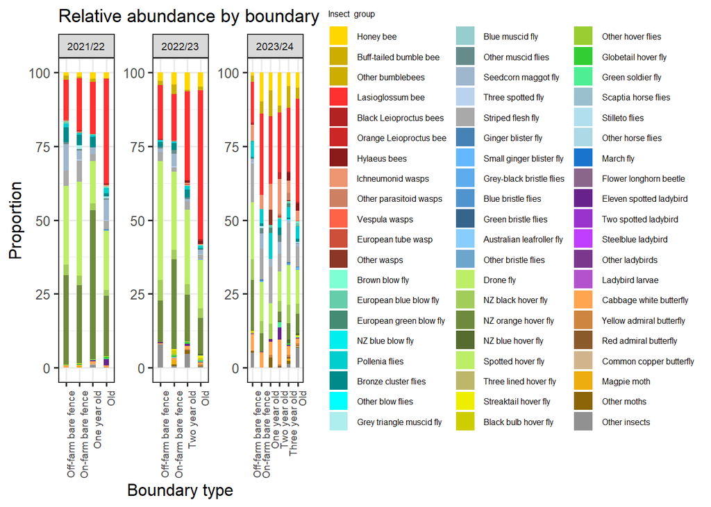

```r
mydf_byboundary_yr<-mydf_byboundary_yr %>% separate_wider_delim(Boundary_year,'_',names=c("Boundary_descriptor","Season"))

#recolour and tidy
mydf_byboundary_yr$Boundary_descriptor <- factor(mydf_byboundary_yr$Boundary_descriptor,levels=c('Off-farm bare fence','On-farm bare fence','One year old','Two year old','Three year old','Old'),ordered = T)

mydf_byboundary_yr %>%   ggplot(aes(x = Boundary_descriptor, y = per, fill = `New Inseck key name`)) +
  geom_bar(position='stack',stat='identity',width=0.4) +
  facet_wrap(~Season,scales="free") +
  theme_bw(base_size = 12) +
  theme(strip.text.x = element_text(angle = 0,size=7),axis.text.x = element_text(angle = 90,size=7,hjust=1),plot.title = element_text(size = 13))+
  scale_fill_manual(values=with(brads_col_2,setNames(Brad_colours,`New Inseck key name`)))+
  ggtitle(paste('Relative abundance by boundary'))+ylab('Proportion')+xlab('Boundary type')+
  labs(fill = "Insect  group")+
  theme(
    legend.text = element_text(size = 6),
    legend.title = element_text(size = 6),
    legend.key.size = unit(1,"line"))
```

## Just a base tests to show that there is significantly more counts by planting age

Just mucking around trying to think of ways to highlight the great raw counts in old, 3 years etc

```r
#switching to raw counts
data<-read_excel('C:/Users/hrlexd/Dropbox/PlantAndFood (1)/B4BI/Pakchoi/Copy of Pak choi pollinators raw visits Brad correctedupdatedEddy.xlsx',sheet='Pak choi raw visits')

#filter out things that are 2018 in Boundary age column
data<-data %>% filter(`Boundary age`!=2018)

brads_col_2<-read_excel('C:/Users/hrlexd/Dropbox/PlantAndFood (1)/B4BI/Pakchoi/Eddy Pie chart short.xlsx',sheet='Colours')
#tidy up some names etc
data$Boundary_descriptor<-gsub('one year old','One year old',data$Boundary_descriptor)
data$Boundary_descriptor<-gsub('two year old','Two year old',data$Boundary_descriptor)
data$Boundary_descriptor<-gsub('three year old','Three year old',data$Boundary_descriptor)
data$Boundary_descriptor<-gsub('Bare_fence','On-farm bare fence',data$Boundary_descriptor)
data$Boundary_descriptor<-gsub('Control_farm','Off-farm bare fence',data$Boundary_descriptor)

unique(data$Boundary_descriptor)
```

```
## [1] "Off-farm bare fence" "One year old"        "Two year old"
## [4] "Three year old"      "Old"                 "On-farm bare fence"
```

```r
colnames(data)
```

```
##  [1] "Farm type"                  "Farm_name"
##  [3] "Season"                     "Boundary_descriptor"
##  [5] "Boundary age"               "Insect key number"
##  [7] "New Inseck key name"        "Sum of Insects/100 flowers"
##  [9] "Broad Insect category"      "Origin"
## [11] "Sum of Insect_Count"        "Flower count"
```

```r
#summarising counts to clean up dataset etc
mydf<-data %>% select(-`Broad Insect category`,-Origin,-`Boundary age`,-`Sum of Insects/100 flowers`)

mydf<-mydf %>% mutate(unique_sample=paste(Boundary_descriptor,Farm_name,Season))

counts<-mydf %>% ungroup() %>% select(unique_sample,`New Inseck key name`,`Sum of Insect_Count`)

#transform wide
counts_wide<-counts %>% pivot_wider(names_from=`New Inseck key name`,values_from = `Sum of Insect_Count`)
counts_wide<-counts_wide %>% remove_rownames %>% column_to_rownames(var="unique_sample")

#meta data
meta_data<-read_excel('C:/Users/hrlexd/Dropbox/PlantAndFood (1)/B4BI/Pakchoi/Copy of Meta_data_pakchoiBH.xlsx',sheet='Meta_data_pakchoi')
rownames(meta_data) <- meta_data$unique_sample
meta_data<-meta_data %>% mutate(month_split=paste(Collection_month,Beg_Mid_end,sep='_'))

#check meta and count data match
setdiff(row.names(counts_wide),meta_data$unique_sample)
```

```
## character(0)
```

```r
#brad colour scheme (control to old):
col_bound<-c('chocolate','#FDE725FF',"#5DC863FF","#21908CFF",'#3B528BFF',"#440154FF")
#col_bound

#ready to analyse!

insect_counts<-rowSums(counts_wide)

insect_counts_df<-data.frame(insect_counts)
insect_counts_df <- rownames_to_column(insect_counts_df, var = "unique_sample")
insect_counts_df<-left_join(insect_counts_df,meta_data)
```

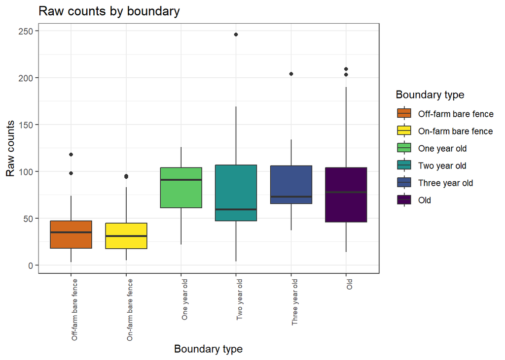

```r
insect_counts_df$Boundary_descriptor <- factor(insect_counts_df$Boundary_descriptor,levels=c('Off-farm bare fence','On-farm bare fence','One year old','Two year old','Three year old','Old'),ordered = T)
#split by season
plot_sppr <- ggplot(insect_counts_df, aes(x = Boundary_descriptor, y = insect_counts, fill = Boundary_descriptor)) +
  geom_boxplot() +
#  facet_wrap(~Season)+
  theme_bw()+
  scale_fill_manual(values=col_bound)+
  labs(x = "Boundary type",
       y = "Raw counts",
       title = "Raw counts by boundary",
       fill = "Boundary type")+
  theme(axis.text.x = element_text(angle = 90,size=7,hjust=1))

plot_sppr
```

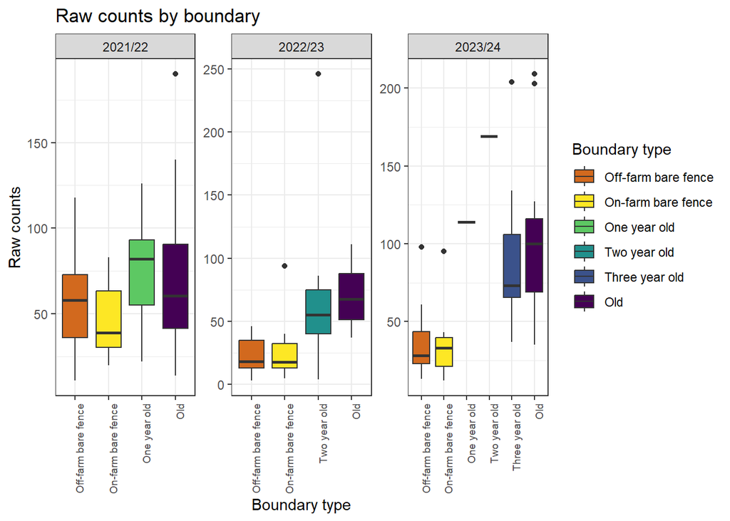

```r
#split by season
plot_sppr <- ggplot(insect_counts_df, aes(x = Boundary_descriptor, y = insect_counts, fill = Boundary_descriptor)) +
  geom_boxplot() +
  facet_wrap(~Season,scales="free")+
  theme_bw()+
  scale_fill_manual(values=col_bound)+
  labs(x = "Boundary type",
       y = "Raw counts",
       title = "Raw counts by boundary",
       fill = "Boundary type")+
  theme(axis.text.x = element_text(angle = 90,size=7,hjust=1))

plot_sppr
```

```r
#issue with model convergence with some random effects so:
m0<-lmer(insect_counts ~ Boundary_descriptor + offset(log(`Flower count`)) +(1|Season) , data = meta_data)
m1<-lmer(insect_counts ~ Boundary_descriptor + offset(log(`Flower count`)) +(1|Season) +(1|Farm_name), data = meta_data)
#im getting a boundary (singular) fit warning with month_split so dropping for this

AIC(m0,m1)
```

```
##    df      AIC
## m0  8 1152.131
## m1  9 1148.108
```

```r
anova(m0,m1)
```

```
## refitting model(s) with ML (instead of REML)
```

```
## Data: meta_data
## Models:
## m0: insect_counts ~ Boundary_descriptor + offset(log(`Flower count`)) + (1 | Season)
## m1: insect_counts ~ Boundary_descriptor + offset(log(`Flower count`)) + (1 | Season) + (1 | Farm_name)
##    npar    AIC    BIC  logLik -2*log(L)  Chisq Df Pr(>Chisq)
## m0    8 1192.7 1214.7 -588.35    1176.7
## m1    9 1188.4 1213.1 -585.20    1170.4 6.2956  1     0.0121 *
## ---
## Signif. codes:  0 '***' 0.001 '**' 0.01 '*' 0.05 '.' 0.1 ' ' 1
```

```r
#final model
m0<-lmer(insect_counts ~ Boundary_descriptor + offset(log(`Flower count`)) +(1|Season) +(1|Farm_name), data = meta_data)
summary(m0)
```

```
## Linear mixed model fit by REML. t-tests use Satterthwaite's method [
## lmerModLmerTest]
## Formula: insect_counts ~ Boundary_descriptor + offset(log(`Flower count`)) +
##     (1 | Season) + (1 | Farm_name)
##    Data: meta_data
##
## REML criterion at convergence: 1130.1
##
## Scaled residuals:
##     Min      1Q  Median      3Q     Max
## -2.0710 -0.5478 -0.0750  0.4490  4.1397
##
## Random effects:
##  Groups    Name        Variance Std.Dev.
##  Farm_name (Intercept)  303.5   17.42
##  Season    (Intercept)  113.1   10.64
##  Residual              1377.0   37.11
## Number of obs: 115, groups:  Farm_name, 19; Season, 3
##
## Fixed effects:
##                                       Estimate Std. Error      df t value
## (Intercept)                             34.015     10.373   8.159   3.279
## Boundary_descriptorOld                  42.613      9.813 106.079   4.342
## Boundary_descriptorOn-farm bare fence   -1.540     10.654 106.669  -0.145
## Boundary_descriptorOne year old         37.416     16.633 102.042   2.249
## Boundary_descriptorThree year old       46.587     16.701 100.606   2.789
## Boundary_descriptorTwo year old         50.988     15.900 102.063   3.207
##                                       Pr(>|t|)
## (Intercept)                            0.01090 *
## Boundary_descriptorOld                3.23e-05 ***
## Boundary_descriptorOn-farm bare fence  0.88533
## Boundary_descriptorOne year old        0.02663 *
## Boundary_descriptorThree year old      0.00632 **
## Boundary_descriptorTwo year old        0.00179 **
## ---
## Signif. codes:  0 '***' 0.001 '**' 0.01 '*' 0.05 '.' 0.1 ' ' 1
##
## Correlation of Fixed Effects:
##                   (Intr) Bndr_O B_O-bf Bn_Oyo Bndry_dscrptrThyo
## Bndry_dscrO       -0.533
## Bndry_dO-bf       -0.492  0.567
## Bndry_dsOyo       -0.304  0.284  0.273
## Bndry_dscrptrThyo -0.280  0.281  0.242  0.188
## Bndry_dscrptrTwyo -0.328  0.319  0.302  0.192  0.201
```

```r
emm2 <- emmeans(m0, ~ Boundary_descriptor,type = "response")
pairs(emm2,simple='each',  adjust = "tukey")
```

```
##  contrast                                     estimate    SE    df t.ratio
##  (Off-farm bare fence) - Old                    -42.61  9.94 106.0  -4.287
##  (Off-farm bare fence) - (On-farm bare fence)     1.54 10.80 106.6   0.142
##  (Off-farm bare fence) - One year old           -37.42 17.10 103.0  -2.188
##  (Off-farm bare fence) - Three year old         -46.59 17.20 101.8  -2.702
##  (Off-farm bare fence) - Two year old           -50.99 16.40 103.1  -3.104
##  Old - (On-farm bare fence)                      44.15  9.60  95.2   4.601
##  Old - One year old                               5.20 17.30 108.6   0.301
##  Old - Three year old                            -3.97 17.50 106.9  -0.227
##  Old - Two year old                              -8.37 16.30 107.3  -0.512
##  (On-farm bare fence) - One year old            -38.96 17.60 108.4  -2.211
##  (On-farm bare fence) - Three year old          -48.13 18.30 106.1  -2.627
##  (On-farm bare fence) - Two year old            -52.53 16.70 107.4  -3.137
##  One year old - Three year old                   -9.17 22.20  95.4  -0.413
##  One year old - Two year old                    -13.57 21.60  95.1  -0.627
##  Three year old - Two year old                   -4.40 21.70  92.8  -0.203
##  p.value
##   0.0006
##   1.0000
##   0.2525
##   0.0836
##   0.0289
##   0.0002
##   0.9997
##   0.9999
##   0.9956
##   0.2411
##   0.0996
##   0.0261
##   0.9984
##   0.9888
##   1.0000
##
## Degrees-of-freedom method: kenward-roger
## P value adjustment: tukey method for comparing a family of 6 estimates
```

```r
#running each as I think all comparisons is a bit over the top and probably repeating things
cld_rich <- multcomp::cld(emm2, Letters = letters, adjust = "tukey")
```

```
## Note: adjust = "tukey" was changed to "sidak"
## because "tukey" is only appropriate for one set of pairwise comparisons
```

```r
colnames(cld_rich)
```

```
## [1] "Boundary_descriptor" "emmean"              "SE"
## [4] "df"                  "lower.CL"            "upper.CL"
## [7] ".group"
```

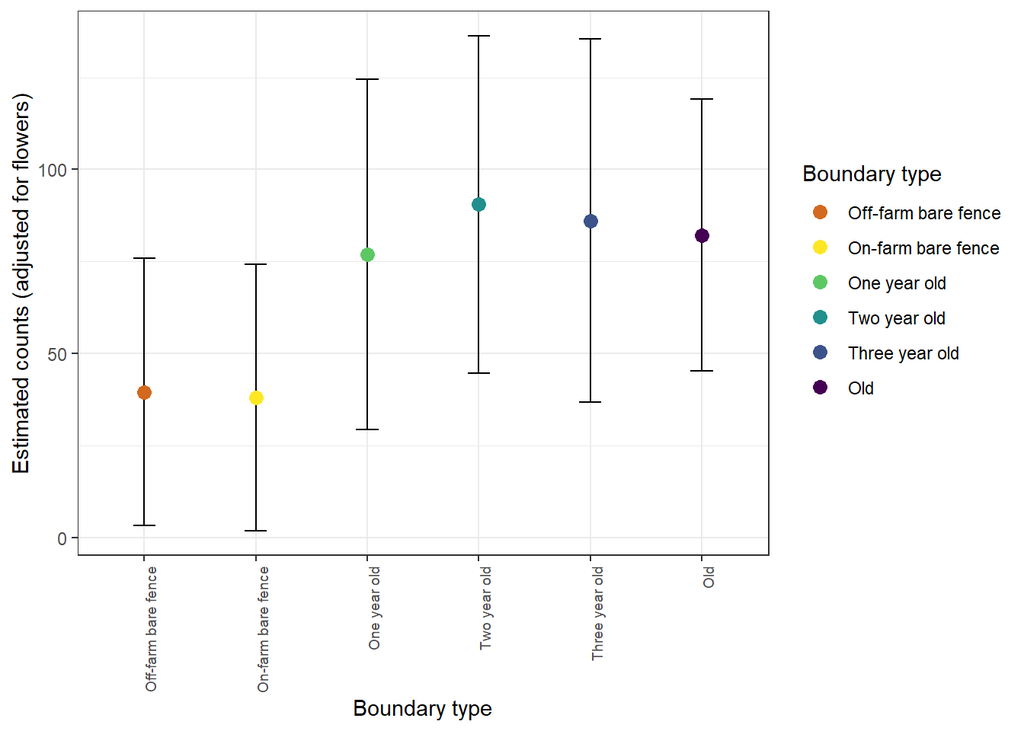

```r
cld_rich$Boundary_descriptor <- factor(cld_rich$Boundary_descriptor,levels=c('Off-farm bare fence','On-farm bare fence','One year old','Two year old','Three year old','Old'),ordered = T)

ggplot(cld_rich, aes(x = Boundary_descriptor, y = emmean)) +
  theme_bw()+
  geom_errorbar(aes(ymin = lower.CL, ymax = upper.CL), width = 0.2) +
  geom_point(size = 3,aes(colour=Boundary_descriptor)) +
  scale_colour_manual(values=col_bound)+
# not sure if groupings will make sense with facet wrap
#  geom_text(aes(label = .group, y = asymp.UCL + 0.2), vjust = 0, size = 5) +
  labs(y = "Estimated counts (adjusted for flowers)", x = "Boundary type", colour='Boundary type') +
  theme(axis.text.x = element_text(angle = 90,size=7,hjust=1))
```

```r
#given how misrabley different they are we are probably safe with just an anova

count_aov <-aov(insect_counts ~ Boundary_descriptor + Season + offset(log(`Flower count`)) , data = meta_data)
summary(count_aov)
```

```
##                      Df Sum Sq Mean Sq F value   Pr(>F)
## Boundary_descriptor   5  63463   12693   7.667 3.42e-06 ***
## Season                2  12532    6266   3.785   0.0258 *
## Residuals           107 177139    1656
## ---
## Signif. codes:  0 '***' 0.001 '**' 0.01 '*' 0.05 '.' 0.1 ' ' 1
```

```r
TukeyHSD(count_aov)
```

```
##   Tukey multiple comparisons of means
##     95% family-wise confidence level
##
## Fit: aov(formula = insect_counts ~ Boundary_descriptor + Season + offset(log(`Flower count`)), data = meta_data)
##
## $Boundary_descriptor
##                                              diff        lwr       upr
## Old-Off-farm bare fence                 44.188208  14.903683  73.47273
## On-farm bare fence-Off-farm bare fence  -1.022724 -32.600330  30.55488
## One year old-Off-farm bare fence        43.187575  -6.536796  92.91195
## Three year old-Off-farm bare fence      55.783539   6.059167 105.50791
## Two year old-Off-farm bare fence        49.401157   2.246680  96.55563
## On-farm bare fence-Old                 -45.210932 -75.097312 -15.32455
## One year old-Old                        -1.000632 -49.668523  47.66726
## Three year old-Old                      11.595331 -37.072560  60.26322
## Two year old-Old                         5.212950 -40.826113  51.25201
## One year old-On-farm bare fence         44.210300  -5.870889  94.29149
## Three year old-On-farm bare fence       56.806263   6.725074 106.88745
## Two year old-On-farm bare fence         50.423881   2.893290  97.95447
## Three year old-One year old             12.595963 -50.518959  75.71088
## Two year old-One year old                6.213582 -54.897178  67.32434
## Two year old-Three year old             -6.382381 -67.493141  54.72838
##                                            p adj
## Old-Off-farm bare fence                0.0003932
## On-farm bare fence-Off-farm bare fence 0.9999989
## One year old-Off-farm bare fence       0.1273660
## Three year old-Off-farm bare fence     0.0184528
## Two year old-Off-farm bare fence       0.0343416
## On-farm bare fence-Old                 0.0003768
## One year old-Old                       0.9999999
## Three year old-Old                     0.9825571
## Two year old-Old                       0.9994784
## One year old-On-farm bare fence        0.1159764
## Three year old-On-farm bare fence      0.0165615
## Two year old-On-farm bare fence        0.0308396
## Three year old-One year old            0.9922068
## Two year old-One year old              0.9996917
## Two year old-Three year old            0.9996485
##
## $Season
##                       diff         lwr       upr     p adj
## 2022/23-2021/22 -17.341745 -39.6769617  4.993471 0.1599249
## 2023/24-2021/22   4.969548 -17.0884805 27.027577 0.8540606
## 2023/24-2022/23  22.311294   0.4045564 44.218031 0.0449068
```

```r
#cough cough bring 3 year down below 0.05 rather than like -.08-0.09 on the full model
```

## Alpha diversity

Species count using species count Im switching to raw counts here, one issue is that flower number varies so need to check the relationship between diversity and flower number

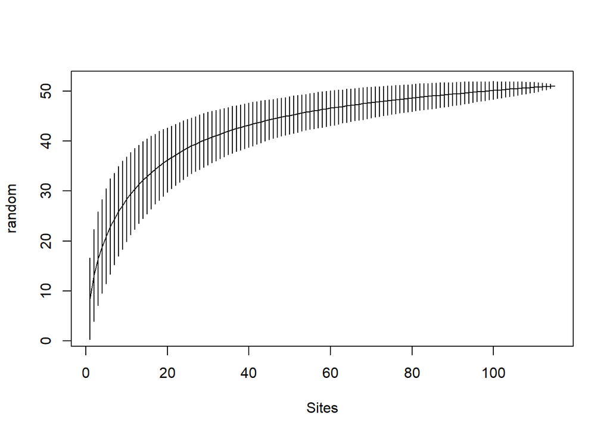

```r
#Alpha diversity
#one matrix of the counts
#one metadata file

#species accumulation curve
speccurve<-specaccum(counts_wide,method='random',permutations=1000)
plot(speccurve)
```

```r
#count species per property
sppr <- specnumber(counts_wide)
head(sppr)
```

```
## Off-farm bare fence Ahuriri 2021/22        One year old Ahuriri 2021/22
##                                   4                                   5
## Off-farm bare fence Ahuriri 2022/23        Two year old Ahuriri 2022/23
##                                   3                                   1
## Off-farm bare fence Ahuriri 2023/24      Three year old Ahuriri 2023/24
##                                   5                                  15
```

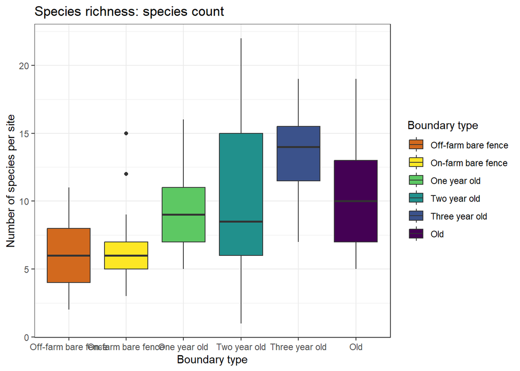

```r
#can plot that out
sppr_df <- sppr %>%
  enframe() %>%
  full_join(meta_data, by = c("name" = "unique_sample"))

sppr_df$Boundary_descriptor <- factor(sppr_df$Boundary_descriptor,levels=c('Off-farm bare fence','On-farm bare fence','One year old','Two year old','Three year old','Old'),ordered = T)

#just boundary
plot_sppr <- ggplot(sppr_df, aes(x = Boundary_descriptor, y = value, fill = Boundary_descriptor)) +
  geom_boxplot() +
  theme_bw()+
  scale_fill_manual(values=col_bound)+
  labs(x = "Boundary type",
       y = "Number of species per site",
       title = "Species richness: species count",
       fill = "Boundary type")
plot_sppr
```

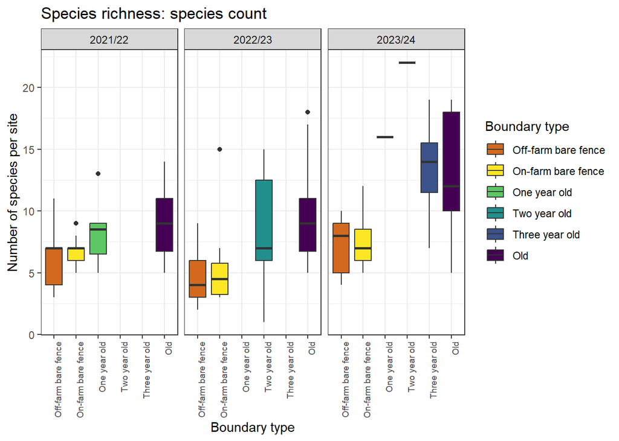

```r
#other significant factor was season
plot_sppr <- ggplot(sppr_df, aes(x = Boundary_descriptor, y = value, fill = Boundary_descriptor)) +
  geom_boxplot() +
facet_wrap(~Season)+
    scale_fill_manual(values=col_bound)+
  theme_bw()+
  labs(x = "Boundary type",
       y = "Number of species per site",
       title = "Species richness: species count",
       fill = "Boundary type")+
  theme(axis.text.x = element_text(angle = 90,size=7,hjust=1))

plot_sppr
```

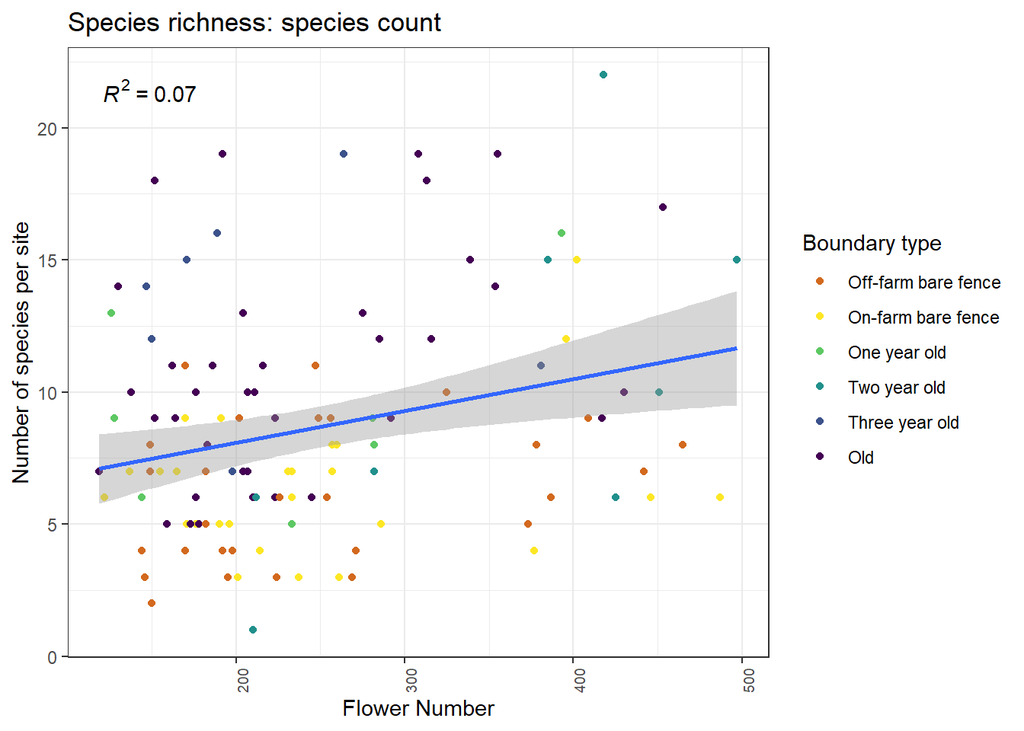

```r
#flower number:
plot_sppr <- ggplot(sppr_df, aes(x = `Flower count`, y = value)) +
  geom_point(aes(colour = Boundary_descriptor)) +
  scale_colour_manual(values=col_bound)+
  stat_poly_line() +
  stat_poly_eq() +
   theme_bw()+
  labs(x = "Flower Number",
       y = "Number of species per site",
       title = "Species richness: species count", colour = "Boundary type")+
  theme(axis.text.x = element_text(angle = 90,size=7,hjust=1))

plot_sppr
```

```r
####season as a random effect
#date split by month (early, mid, late) and farm name
logLik(lmer(sppr ~ Boundary_descriptor + offset(log(`Flower count`))+(1|Season), data = meta_data))
```

```
## 'log Lik.' -298.2743 (df=8)
```

```r
m0<-lmer(sppr ~ Boundary_descriptor + offset(log(`Flower count`))+(1|Season), data = meta_data)
logLik(lmer(sppr ~ Boundary_descriptor + offset(log(`Flower count`))+(1|Season) + (1|Farm_name) , data = meta_data))
```

```
## 'log Lik.' -297.8165 (df=9)
```

```r
m1<-lmer(sppr ~ Boundary_descriptor + offset(log(`Flower count`))+(1|Season) + (1|Farm_name) , data = meta_data)
logLik(lmer(sppr ~ Boundary_descriptor + offset(log(`Flower count`))+(1|Season) + (1|Collection_month) + (1|Site), data = meta_data))
```

```
## 'log Lik.' -296.5371 (df=10)
```

```r
m2<-lmer(sppr ~ Boundary_descriptor + offset(log(`Flower count`))+(1|Season) + (1|Collection_month) + (1|Farm_name), data = meta_data)
logLik(lmer(sppr ~ Boundary_descriptor + offset(log(`Flower count`))+(1|Season) + (1|month_split) + (1|Farm_name), data = meta_data))
```

```
## 'log Lik.' -295.3321 (df=10)
```

```r
m3<-lmer(sppr ~ Boundary_descriptor + offset(log(`Flower count`))+(1|Season) + (1|month_split) + (1|Farm_name), data = meta_data)

AIC(m0,m1,m2,m3)
```

```
##    df      AIC
## m0  8 612.5486
## m1  9 613.6329
## m2 10 610.8053
## m3 10 610.6642
```

```r
anova(m0,m1,m2,m3)
```

```
## refitting model(s) with ML (instead of REML)
```

```
## Data: meta_data
## Models:
## m0: sppr ~ Boundary_descriptor + offset(log(`Flower count`)) + (1 | Season)
## m1: sppr ~ Boundary_descriptor + offset(log(`Flower count`)) + (1 | Season) + (1 | Farm_name)
## m2: sppr ~ Boundary_descriptor + offset(log(`Flower count`)) + (1 | Season) + (1 | Collection_month) + (1 | Farm_name)
## m3: sppr ~ Boundary_descriptor + offset(log(`Flower count`)) + (1 | Season) + (1 | month_split) + (1 | Farm_name)
##    npar    AIC    BIC  logLik -2*log(L)  Chisq Df Pr(>Chisq)
## m0    8 624.27 646.23 -304.14    608.27
## m1    9 625.18 649.88 -303.59    607.18 1.0976  1    0.29480
## m2   10 622.40 649.84 -301.20    602.40 4.7821  1    0.02876 *
## m3   10 621.70 649.15 -300.85    601.70 0.6943  0
## ---
## Signif. codes:  0 '***' 0.001 '**' 0.01 '*' 0.05 '.' 0.1 ' ' 1
```

```r
#this is all really marginal so be honest
#in my mind all these are so marginal but for explaining in a paper it may look better to say farm and month were included as random effects:

#so date and season as random effect
#month_split + farm name + season
m3<-lmer(sppr ~ Boundary_descriptor + offset(log(`Flower count`))+(1|Season) + (1|month_split) + (1|Farm_name), data = meta_data)
summary(m3)
```

```
## Linear mixed model fit by REML. t-tests use Satterthwaite's method [
## lmerModLmerTest]
## Formula: sppr ~ Boundary_descriptor + offset(log(`Flower count`)) + (1 |
##     Season) + (1 | month_split) + (1 | Farm_name)
##    Data: meta_data
##
## REML criterion at convergence: 590.7
##
## Scaled residuals:
##      Min       1Q   Median       3Q      Max
## -2.28681 -0.61770 -0.04423  0.46589  2.59136
##
## Random effects:
##  Groups      Name        Variance Std.Dev.
##  Farm_name   (Intercept) 1.349    1.1616
##  month_split (Intercept) 1.992    1.4115
##  Season      (Intercept) 0.977    0.9884
##  Residual                9.383    3.0632
## Number of obs: 115, groups:  Farm_name, 19; month_split, 9; Season, 3
##
## Fixed effects:
##                                       Estimate Std. Error       df t value
## (Intercept)                             1.1340     0.9998   8.5240   1.134
## Boundary_descriptorOld                  4.4074     0.8096  99.4736   5.444
## Boundary_descriptorOn-farm bare fence   0.3201     0.8720 100.3420   0.367
## Boundary_descriptorOne year old         3.0984     1.3988  95.5061   2.215
## Boundary_descriptorThree year old       5.2195     1.4269  90.2508   3.658
## Boundary_descriptorTwo year old         3.5363     1.3388  86.9749   2.641
##                                       Pr(>|t|)
## (Intercept)                           0.287581
## Boundary_descriptorOld                3.76e-07 ***
## Boundary_descriptorOn-farm bare fence 0.714333
## Boundary_descriptorOne year old       0.029132 *
## Boundary_descriptorThree year old     0.000427 ***
## Boundary_descriptorTwo year old       0.009787 **
## ---
## Signif. codes:  0 '***' 0.001 '**' 0.01 '*' 0.05 '.' 0.1 ' ' 1
##
## Correlation of Fixed Effects:
##                   (Intr) Bndr_O B_O-bf Bn_Oyo Bndry_dscrptrThyo
## Bndry_dscrO       -0.439
## Bndry_dO-bf       -0.407  0.561
## Bndry_dsOyo       -0.267  0.278  0.261
## Bndry_dscrptrThyo -0.223  0.256  0.234  0.152
## Bndry_dscrptrTwyo -0.276  0.328  0.303  0.156  0.164
```

```r
#back transform to species count
emm1 <- emmeans(m3, ~ Boundary_descriptor, type = "response")
#pairwise test
pairs(emm1, simple='each', adjust = "tukey")
```

```
##  contrast                                     estimate    SE    df t.ratio
##  (Off-farm bare fence) - Old                    -4.407 0.825 102.0  -5.344
##  (Off-farm bare fence) - (On-farm bare fence)   -0.320 0.890 101.8  -0.360
##  (Off-farm bare fence) - One year old           -3.098 1.440 102.7  -2.148
##  (Off-farm bare fence) - Three year old         -5.220 1.480 100.2  -3.537
##  (Off-farm bare fence) - Two year old           -3.536 1.400  98.5  -2.525
##  Old - (On-farm bare fence)                      4.087 0.795  90.8   5.141
##  Old - One year old                              1.309 1.460 108.1   0.895
##  Old - Three year old                           -0.812 1.520 105.5  -0.535
##  Old - Two year old                              0.871 1.370 103.7   0.635
##  (On-farm bare fence) - One year old            -2.778 1.490 107.8  -1.866
##  (On-farm bare fence) - Three year old          -4.899 1.560 104.8  -3.143
##  (On-farm bare fence) - Two year old            -3.216 1.420 103.7  -2.270
##  One year old - Three year old                  -2.121 1.930  99.6  -1.100
##  One year old - Two year old                    -0.438 1.880  96.5  -0.233
##  Three year old - Two year old                   1.683 1.900  92.3   0.888
##  p.value
##   <.0001
##   0.9992
##   0.2713
##   0.0079
##   0.1269
##   <.0001
##   0.9468
##   0.9946
##   0.9881
##   0.4287
##   0.0258
##   0.2157
##   0.8805
##   0.9999
##   0.9486
##
## Degrees-of-freedom method: kenward-roger
## P value adjustment: tukey method for comparing a family of 6 estimates
```

```r
#pairs(emm1, by='Boundary_descriptor', adjust = "tukey")
#running each as I think all comparisons is a bit over the top and probably repeating things
cld_rich <- multcomp::cld(emm1, Letters = letters, adjust = "tukey")
```

```
## Note: adjust = "tukey" was changed to "sidak"
## because "tukey" is only appropriate for one set of pairwise comparisons
```

```r
colnames(cld_rich)
```

```
## [1] "Boundary_descriptor" "emmean"              "SE"
## [4] "df"                  "lower.CL"            "upper.CL"
## [7] ".group"
```

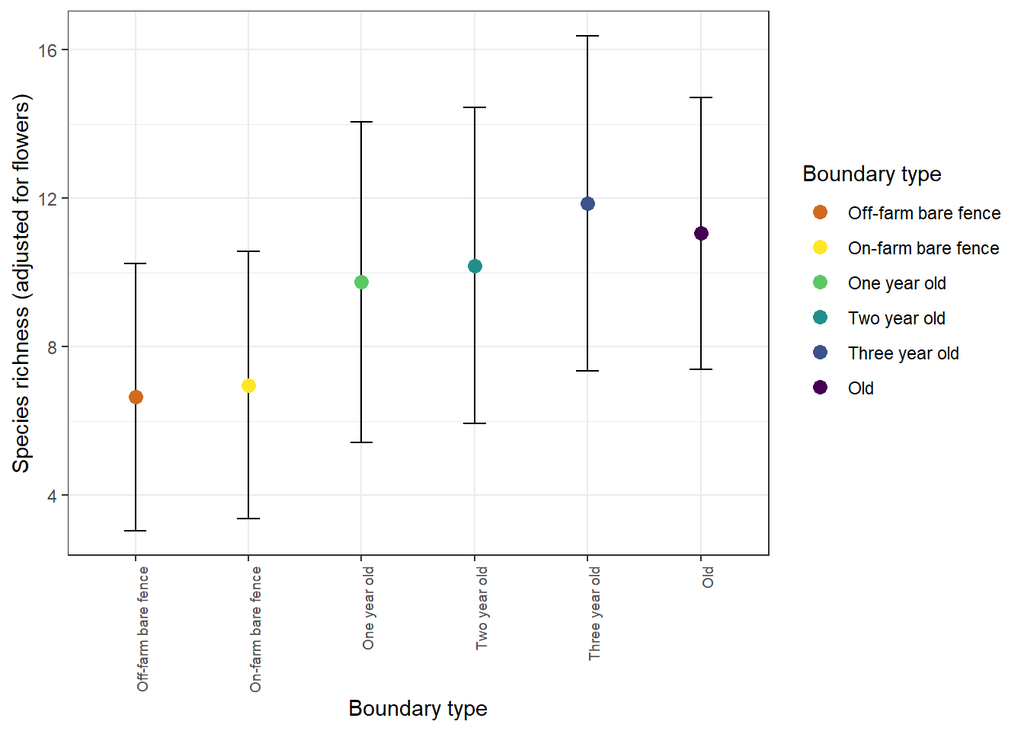

```r
cld_rich$Boundary_descriptor <- factor(cld_rich$Boundary_descriptor,levels=c('Off-farm bare fence','On-farm bare fence','One year old','Two year old','Three year old','Old'),ordered = T)

ggplot(cld_rich, aes(x = Boundary_descriptor, y = emmean)) +
  theme_bw()+
  geom_errorbar(aes(ymin = lower.CL, ymax = upper.CL), width = 0.2) +
  geom_point(size = 3,aes(colour=Boundary_descriptor)) +
  scale_colour_manual(values=col_bound)+
# not sure if groupings will make sense with facet wrap
#  geom_text(aes(label = .group, y = asymp.UCL + 0.2), vjust = 0, size = 5) +
  labs(y = "Species richness (adjusted for flowers)", x = "Boundary type", colour='Boundary type') +
  theme(axis.text.x = element_text(angle = 90,size=7,hjust=1))
```

```r
#but this is really a marginal on those random effects and if you just do a standard anova:
#flower count as a offset
sppr_aov <-aov(sppr ~ Boundary_descriptor + Season + offset(log(`Flower count`)) , data = meta_data)
summary(sppr_aov)
```

```
##                      Df Sum Sq Mean Sq F value  Pr(>F)
## Boundary_descriptor   5  661.7  132.34  11.466 7.1e-09 ***
## Season                2  208.2  104.08   9.018 0.00024 ***
## Residuals           107 1234.9   11.54
## ---
## Signif. codes:  0 '***' 0.001 '**' 0.01 '*' 0.05 '.' 0.1 ' ' 1
```

```r
TukeyHSD(sppr_aov)
```

```
##   Tukey multiple comparisons of means
##     95% family-wise confidence level
##
## Fit: aov(formula = sppr ~ Boundary_descriptor + Season + offset(log(`Flower count`)), data = meta_data)
##
## $Boundary_descriptor
##                                              diff        lwr       upr
## Old-Off-farm bare fence                 4.6206400  2.1755064  7.065773
## On-farm bare fence-Off-farm bare fence  0.2735721 -2.3630240  2.910168
## One year old-Off-farm bare fence        3.3304326 -0.8213414  7.482207
## Three year old-Off-farm bare fence      7.3549671  3.2031931 11.506741
## Two year old-Off-farm bare fence        3.6511572 -0.2860416  7.588356
## On-farm bare fence-Old                 -4.3470679 -6.8424538 -1.851682
## One year old-Old                       -1.2902073 -5.3537697  2.773355
## Three year old-Old                      2.7343271 -1.3292352  6.797889
## Two year old-Old                       -0.9694828 -4.8135491  2.874584
## One year old-On-farm bare fence         3.0568605 -1.1247061  7.238427
## Three year old-On-farm bare fence       7.0813950  2.8998283 11.262962
## Two year old-On-farm bare fence         3.3775851 -0.5910175  7.346188
## Three year old-One year old             4.0245345 -1.2452936  9.294363
## Two year old-One year old               0.3207246 -4.7817645  5.423214
## Two year old-Three year old            -3.7038099 -8.8062990  1.398679
##                                            p adj
## Old-Off-farm bare fence                0.0000041
## On-farm bare fence-Off-farm bare fence 0.9996595
## One year old-Off-farm bare fence       0.1921362
## Three year old-Off-farm bare fence     0.0000181
## Two year old-Off-farm bare fence       0.0854445
## On-farm bare fence-Old                 0.0000260
## One year old-Old                       0.9402087
## Three year old-Old                     0.3764134
## Two year old-Old                       0.9775495
## One year old-On-farm bare fence        0.2842797
## Three year old-On-farm bare fence      0.0000468
## Two year old-On-farm bare fence        0.1425052
## Three year old-One year old            0.2390218
## Two year old-One year old              0.9999713
## Two year old-Three year old            0.2918611
##
## $Season
##                       diff        lwr       upr     p adj
## 2022/23-2021/22 -0.9071981 -2.7720939 0.9576976 0.4819277
## 2023/24-2021/22  2.0229909  0.1812391 3.8647426 0.0276703
## 2023/24-2022/23  2.9301890  1.1010694 4.7593086 0.0006814
```

```r
#the significant pairs of boundary types are exactly the same between the full model and the anova
```

## Alpha diversity shannon

Alpha diversity using shannon

```r
shannondiv<-diversity(counts_wide)
head(shannondiv)
```

```
## Off-farm bare fence Ahuriri 2021/22        One year old Ahuriri 2021/22
##                           1.0335621                           0.7261928
## Off-farm bare fence Ahuriri 2022/23        Two year old Ahuriri 2022/23
##                           1.0986123                           0.0000000
## Off-farm bare fence Ahuriri 2023/24      Three year old Ahuriri 2023/24
##                           1.1465958                           2.1730992
```

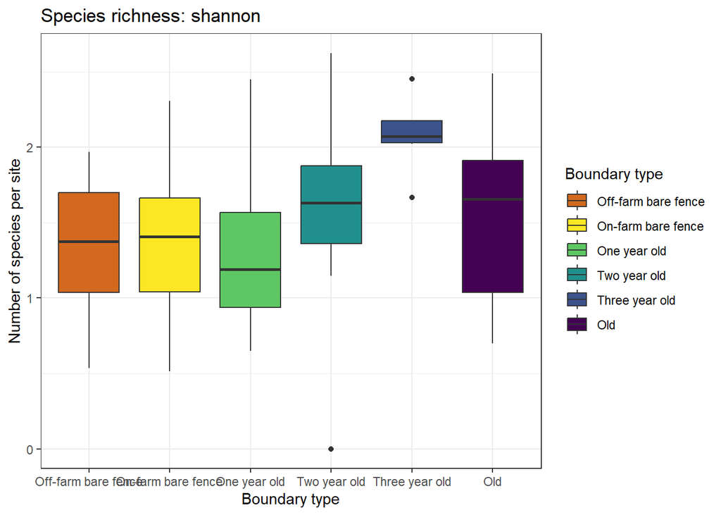

```r
#can plot that out
shannondiv_df <- shannondiv %>%
  enframe() %>%
  full_join(meta_data, by = c("name" = "unique_sample"))

shannondiv_df$Boundary_descriptor <- factor(shannondiv_df$Boundary_descriptor,levels=c('Off-farm bare fence','On-farm bare fence','One year old','Two year old','Three year old','Old'),ordered = T)


#just boundary
plot_sppr <- ggplot(shannondiv_df, aes(x = Boundary_descriptor, y = value, fill = Boundary_descriptor)) +
  geom_boxplot() +
  theme_bw()+
  scale_fill_manual(values=col_bound)+
  labs(x = "Boundary type",
       y = "Number of species per site",
       title = "Species richness: shannon",
       fill = "Boundary type")
plot_sppr
```

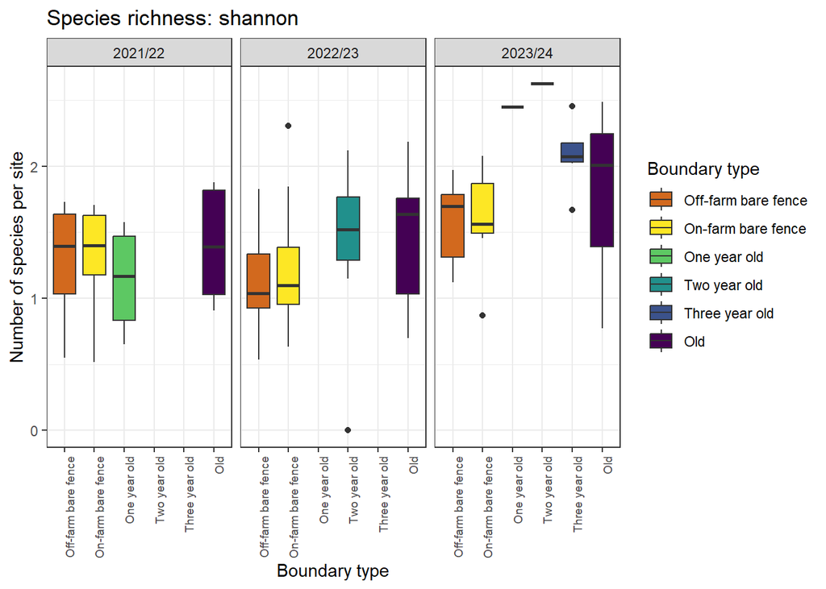

```r
#split by season
plot_sppr <- ggplot(shannondiv_df, aes(x = Boundary_descriptor, y = value, fill = Boundary_descriptor)) +
  geom_boxplot() +
  facet_wrap(~Season)+
  theme_bw()+
  scale_fill_manual(values=col_bound)+
  labs(x = "Boundary type",
       y = "Number of species per site",
       title = "Species richness: shannon",
       fill = "Boundary type")+
  theme(axis.text.x = element_text(angle = 90,size=7,hjust=1))

plot_sppr
```

```r
####season as random effect
logLik(lmer(shannondiv ~ Boundary_descriptor+ offset(log(`Flower count`))+(1|Season), data = meta_data))
```

```
## 'log Lik.' -84.87288 (df=8)
```

```r
m0<-lmer(shannondiv ~ Boundary_descriptor+ offset(log(`Flower count`))+(1|Season), data = meta_data)
logLik(lmer(shannondiv ~ Boundary_descriptor+ offset(log(`Flower count`))+(1|Season) + (1|Farm_name) , data = meta_data))
```

```
## 'log Lik.' -81.80415 (df=9)
```

```r
m1<-lmer(shannondiv ~ Boundary_descriptor+ offset(log(`Flower count`))+(1|Season) + (1|Farm_name) , data = meta_data)
logLik(lmer(shannondiv ~ Boundary_descriptor+ offset(log(`Flower count`))+(1|Season) + (1|month_split) , data = meta_data))
```

```
## 'log Lik.' -82.63968 (df=9)
```

```r
m2<-lmer(shannondiv ~ Boundary_descriptor+ offset(log(`Flower count`))+(1|Season) + (1|month_split) , data = meta_data)
logLik(lmer(shannondiv ~ Boundary_descriptor + offset(log(`Flower count`))+(1|Season) + (1|month_split) + (1|Farm_name), data = meta_data))
```

```
## 'log Lik.' -79.37426 (df=10)
```

```r
m3<-lmer(shannondiv ~ Boundary_descriptor + offset(log(`Flower count`))+(1|Season) + (1|month_split) + (1|Farm_name), data = meta_data)

AIC(m0,m1,m2,m3)
```

```
##    df      AIC
## m0  8 185.7458
## m1  9 181.6083
## m2  9 183.2794
## m3 10 178.7485
```

```r
anova(m0,m1,m2,m3)
```

```
## refitting model(s) with ML (instead of REML)
```

```
## Data: meta_data
## Models:
## m0: shannondiv ~ Boundary_descriptor + offset(log(`Flower count`)) + (1 | Season)
## m1: shannondiv ~ Boundary_descriptor + offset(log(`Flower count`)) + (1 | Season) + (1 | Farm_name)
## m2: shannondiv ~ Boundary_descriptor + offset(log(`Flower count`)) + (1 | Season) + (1 | month_split)
## m3: shannondiv ~ Boundary_descriptor + offset(log(`Flower count`)) + (1 | Season) + (1 | month_split) + (1 | Farm_name)
##    npar    AIC    BIC  logLik -2*log(L)  Chisq Df Pr(>Chisq)
## m0    8 174.11 196.07 -79.055    158.11
## m1    9 169.56 194.26 -75.779    151.56 6.5520  1   0.010477 *
## m2    9 171.60 196.30 -76.798    153.60 0.0000  0
## m3   10 166.69 194.14 -73.343    146.69 6.9101  1   0.008571 **
## ---
## Signif. codes:  0 '***' 0.001 '**' 0.01 '*' 0.05 '.' 0.1 ' ' 1
```

```r
#m3 model which has date and site grouping....

m3<-lmer(shannondiv ~ Boundary_descriptor + offset(log(`Flower count`))+(1|Season) + (1|month_split) + (1|Farm_name), data = meta_data)
summary(m3)
```

```
## Linear mixed model fit by REML. t-tests use Satterthwaite's method [
## lmerModLmerTest]
## Formula: shannondiv ~ Boundary_descriptor + offset(log(`Flower count`)) +
##     (1 | Season) + (1 | month_split) + (1 | Farm_name)
##    Data: meta_data
##
## REML criterion at convergence: 158.7
##
## Scaled residuals:
##      Min       1Q   Median       3Q      Max
## -2.06156 -0.68013  0.05866  0.61972  2.31425
##
## Random effects:
##  Groups      Name        Variance Std.Dev.
##  Farm_name   (Intercept) 0.03676  0.1917
##  month_split (Intercept) 0.02666  0.1633
##  Season      (Intercept) 0.07331  0.2708
##  Residual                0.17189  0.4146
## Number of obs: 115, groups:  Farm_name, 19; month_split, 9; Season, 3
##
## Fixed effects:
##                                        Estimate Std. Error        df t value
## (Intercept)                            -4.04651    0.19084   3.21972 -21.204
## Boundary_descriptorOld                  0.20891    0.11069 101.29251   1.887
## Boundary_descriptorOn-farm bare fence  -0.01735    0.11951 100.86712  -0.145
## Boundary_descriptorOne year old        -0.04475    0.19089 101.20858  -0.234
## Boundary_descriptorThree year old       0.53868    0.19464  99.68431   2.768
## Boundary_descriptorTwo year old        -0.02804    0.18407 100.63925  -0.152
##                                       Pr(>|t|)
## (Intercept)                           0.000144 ***
## Boundary_descriptorOld                0.061980 .
## Boundary_descriptorOn-farm bare fence 0.884860
## Boundary_descriptorOne year old       0.815127
## Boundary_descriptorThree year old     0.006733 **
## Boundary_descriptorTwo year old       0.879230
## ---
## Signif. codes:  0 '***' 0.001 '**' 0.01 '*' 0.05 '.' 0.1 ' ' 1
##
## Correlation of Fixed Effects:
##                   (Intr) Bndr_O B_O-bf Bn_Oyo Bndry_dscrptrThyo
## Bndry_dscrO       -0.317
## Bndry_dO-bf       -0.294  0.569
## Bndry_dsOyo       -0.187  0.270  0.258
## Bndry_dscrptrThyo -0.157  0.247  0.222  0.153
## Bndry_dscrptrTwyo -0.197  0.323  0.299  0.153  0.158
```

```r
emm2 <- emmeans(m3, ~ Boundary_descriptor,type = "response")
pairs(emm2,simple='each',  adjust = "tukey")
```

```
##  contrast                                     estimate    SE    df t.ratio
##  (Off-farm bare fence) - Old                   -0.2089 0.113 101.2  -1.856
##  (Off-farm bare fence) - (On-farm bare fence)   0.0173 0.121 100.5   0.143
##  (Off-farm bare fence) - One year old           0.0448 0.195 101.1   0.230
##  (Off-farm bare fence) - Three year old        -0.5387 0.200  99.5  -2.699
##  (Off-farm bare fence) - Two year old           0.0280 0.190 100.3   0.148
##  Old - (On-farm bare fence)                     0.2263 0.108  90.0   2.099
##  Old - One year old                             0.2537 0.198 106.9   1.280
##  Old - Three year old                          -0.3298 0.206 105.3  -1.602
##  Old - Two year old                             0.2369 0.187 104.0   1.269
##  (On-farm bare fence) - One year old            0.0274 0.202 106.5   0.136
##  (On-farm bare fence) - Three year old         -0.5560 0.211 105.0  -2.633
##  (On-farm bare fence) - Two year old            0.0107 0.193 104.5   0.055
##  One year old - Three year old                 -0.5834 0.258  99.2  -2.261
##  One year old - Two year old                   -0.0167 0.253  98.7  -0.066
##  Three year old - Two year old                  0.5667 0.256  97.0   2.217
##  p.value
##   0.4350
##   1.0000
##   0.9999
##   0.0844
##   1.0000
##   0.2970
##   0.7951
##   0.5991
##   0.8012
##   1.0000
##   0.0985
##   1.0000
##   0.2200
##   1.0000
##   0.2396
##
## Degrees-of-freedom method: kenward-roger
## P value adjustment: tukey method for comparing a family of 6 estimates
```

```r
#running each as I think all comparisons is a bit over the top and probably repeating things
cld_rich <- multcomp::cld(emm2, Letters = letters, adjust = "tukey")
```

```
## Note: adjust = "tukey" was changed to "sidak"
## because "tukey" is only appropriate for one set of pairwise comparisons
```

```r
colnames(cld_rich)
```

```
## [1] "Boundary_descriptor" "emmean"              "SE"
## [4] "df"                  "lower.CL"            "upper.CL"
## [7] ".group"
```

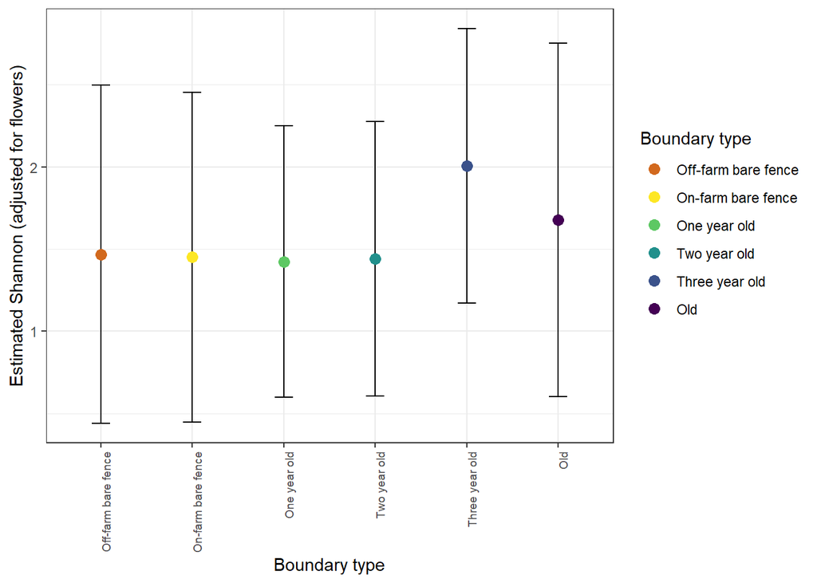

```r
cld_rich$Boundary_descriptor <- factor(cld_rich$Boundary_descriptor,levels=c('Off-farm bare fence','On-farm bare fence','One year old','Two year old','Three year old','Old'),ordered = T)

ggplot(cld_rich, aes(x = Boundary_descriptor, y = emmean)) +
#  facet_wrap(~Season)+
  theme_bw()+
  geom_errorbar(aes(ymin = lower.CL, ymax = upper.CL), width = 0.2) +
  geom_point(size = 3,aes(colour=Boundary_descriptor)) +
  scale_colour_manual(values=col_bound)+
# not sure if groupings will make sense with facet wrap
#  geom_text(aes(label = .group, y = asymp.UCL + 0.2), vjust = 0, size = 5) +
  labs(y = "Estimated Shannon (adjusted for flowers)", x = "Boundary type", colour='Boundary type') +
  theme(axis.text.x = element_text(angle = 90,size=7,hjust=1))
```

```r
#just runing an anova instead
#flower count as a offset
sppr_aov <-aov(shannondiv ~ Boundary_descriptor + Season + offset(log(`Flower count`)) , data = meta_data)
summary(sppr_aov)
```

```
##                      Df Sum Sq Mean Sq F value   Pr(>F)
## Boundary_descriptor   5  6.131  1.2262   5.345    2e-04 ***
## Season                2  4.676  2.3381  10.192 8.88e-05 ***
## Residuals           107 24.547  0.2294
## ---
## Signif. codes:  0 '***' 0.001 '**' 0.01 '*' 0.05 '.' 0.1 ' ' 1
```

```r
TukeyHSD(sppr_aov)
```

```
##   Tukey multiple comparisons of means
##     95% family-wise confidence level
##
## Fit: aov(formula = shannondiv ~ Boundary_descriptor + Season + offset(log(`Flower count`)), data = meta_data)
##
## $Boundary_descriptor
##                                               diff         lwr         upr
## Old-Off-farm bare fence                 0.25758604 -0.08714320  0.60231528
## On-farm bare fence-Off-farm bare fence  0.01434674 -0.35737601  0.38606950
## One year old-Off-farm bare fence        0.08585747 -0.49948393  0.67119887
## Three year old-Off-farm bare fence      0.86831567  0.28297426  1.45365707
## Two year old-Off-farm bare fence       -0.19555728 -0.75064661  0.35953205
## On-farm bare fence-Old                 -0.24323929 -0.59505341  0.10857482
## One year old-Old                       -0.17172857 -0.74463338  0.40117625
## Three year old-Old                      0.61072963  0.03782482  1.18363444
## Two year old-Old                       -0.45314332 -0.99510230  0.08881566
## One year old-On-farm bare fence         0.07151073 -0.51803103  0.66105248
## Three year old-On-farm bare fence       0.85396892  0.26442717  1.44351068
## Two year old-On-farm bare fence        -0.20990402 -0.76942086  0.34961281
## Three year old-One year old             0.78245819  0.03948698  1.52542941
## Two year old-One year old              -0.28141475 -1.00079354  0.43796404
## Two year old-Three year old            -1.06387295 -1.78325174 -0.34449416
##                                            p adj
## Old-Off-farm bare fence                0.2612413
## On-farm bare fence-Off-farm bare fence 0.9999975
## One year old-Off-farm bare fence       0.9981754
## Three year old-Off-farm bare fence     0.0005207
## Two year old-Off-farm bare fence       0.9094861
## On-farm bare fence-Old                 0.3456147
## One year old-Old                       0.9528540
## Three year old-Old                     0.0295634
## Two year old-Old                       0.1565291
## One year old-On-farm bare fence        0.9992707
## Three year old-On-farm bare fence      0.0007606
## Two year old-On-farm bare fence        0.8849051
## Three year old-One year old            0.0328445
## Two year old-One year old              0.8655840
## Two year old-Three year old            0.0005473
##
## $Season
##                        diff        lwr        upr     p adj
## 2022/23-2021/22 -0.34038613 -0.6033101 -0.0774622 0.0074285
## 2023/24-2021/22  0.08829219 -0.1713688  0.3479531 0.6987991
## 2023/24-2022/23  0.42867832  0.1707983  0.6865583 0.0004085
```

## Alpha diversity simpson

Alpha diversity using simpson

```r
simpsondiv<-diversity(counts_wide,index='simpson')
head(simpsondiv)
```

```
## Off-farm bare fence Ahuriri 2021/22        One year old Ahuriri 2021/22
##                           0.5454545                           0.3223140
## Off-farm bare fence Ahuriri 2022/23        Two year old Ahuriri 2022/23
##                           0.6666667                           0.0000000
## Off-farm bare fence Ahuriri 2023/24      Three year old Ahuriri 2023/24
##                           0.5867769                           0.8310322
```

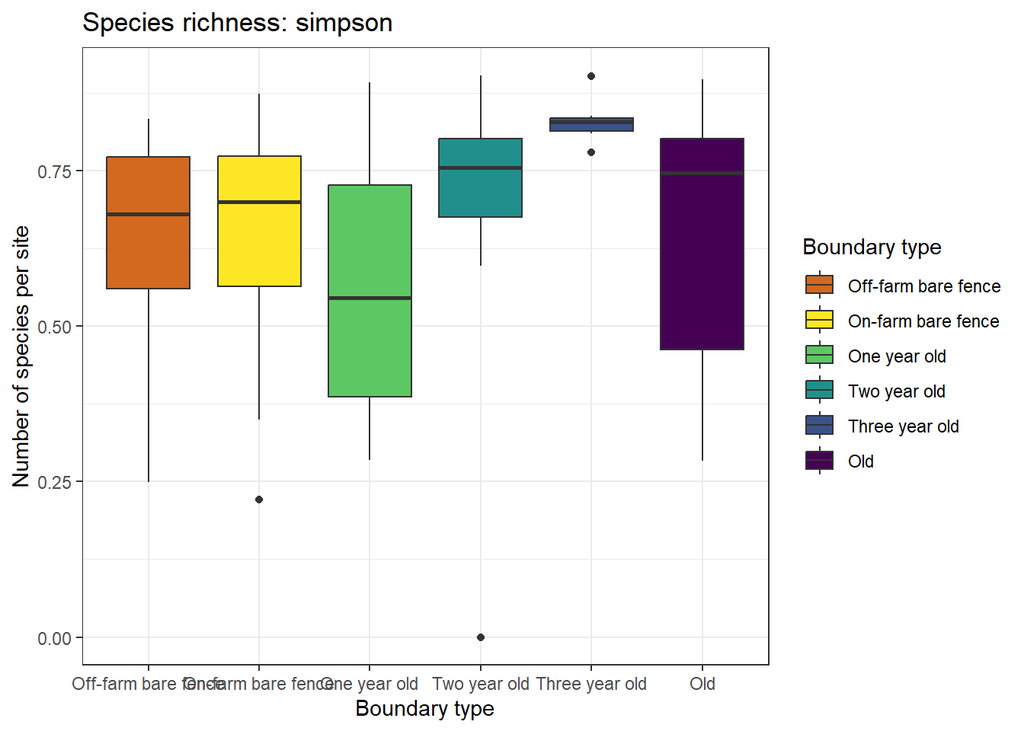

```r
#can plot that out
simpsondiv_df <- simpsondiv %>%
  enframe() %>%
  full_join(meta_data, by = c("name" = "unique_sample"))

simpsondiv_df$Boundary_descriptor <- factor(simpsondiv_df$Boundary_descriptor,levels=c('Off-farm bare fence','On-farm bare fence','One year old','Two year old','Three year old','Old'),ordered = T)


#just boundary
plot_sppr <- ggplot(simpsondiv_df, aes(x = Boundary_descriptor, y = value, fill = Boundary_descriptor)) +
  geom_boxplot() +
  theme_bw()+
  scale_fill_manual(values=col_bound)+
  labs(x = "Boundary type",
       y = "Number of species per site",
       title = "Species richness: simpson",
       fill = "Boundary type")
plot_sppr
```

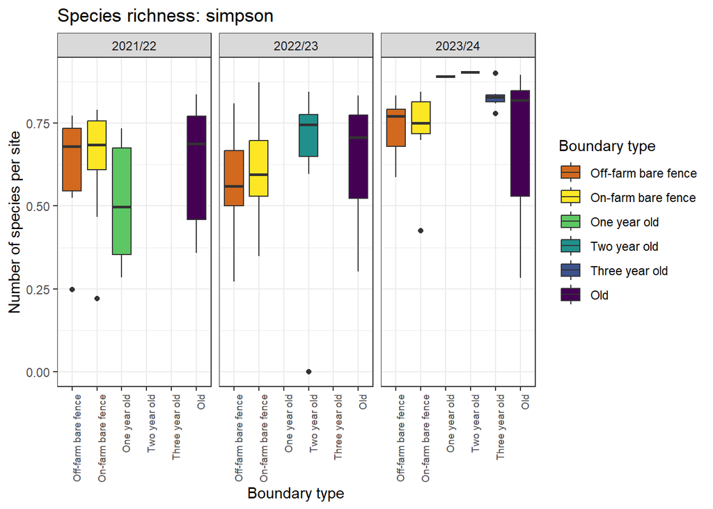

```r
#split by season
plot_sppr <- ggplot(simpsondiv_df, aes(x = Boundary_descriptor, y = value, fill = Boundary_descriptor)) +
  geom_boxplot() +
  facet_wrap(~Season)+
  theme_bw()+
  scale_fill_manual(values=col_bound)+
  labs(x = "Boundary type",
       y = "Number of species per site",
       title = "Species richness: simpson",
       fill = "Boundary type")+
  theme(axis.text.x = element_text(angle = 90,size=7,hjust=1))

plot_sppr
```

```r
####season as random effect
logLik(lmer(simpsondiv ~ Boundary_descriptor+ offset(log(`Flower count`))+(1|Season), data = meta_data))
```

```
## 'log Lik.' -45.42901 (df=8)
```

```r
m0<-lmer(simpsondiv  ~ Boundary_descriptor+ offset(log(`Flower count`))+(1|Season), data = meta_data)
logLik(lmer(simpsondiv ~ Boundary_descriptor+ offset(log(`Flower count`))+(1|Season) + (1|Farm_name) , data = meta_data))
```

```
## 'log Lik.' -43.08179 (df=9)
```

```r
m1<-lmer(simpsondiv ~ Boundary_descriptor+ offset(log(`Flower count`))+(1|Season) + (1|Farm_name) , data = meta_data)
logLik(lmer(simpsondiv ~ Boundary_descriptor+ offset(log(`Flower count`))+(1|Season) + (1|month_split) , data = meta_data))
```

```
## 'log Lik.' -43.04209 (df=9)
```

```r
m2<-lmer(simpsondiv ~ Boundary_descriptor+ offset(log(`Flower count`))+(1|Season) + (1|month_split) , data = meta_data)
logLik(lmer(simpsondiv ~ Boundary_descriptor+ offset(log(`Flower count`))+(1|Season) + (1|month_split) + (1|Farm_name), data = meta_data))
```

```
## 'log Lik.' -40.22581 (df=10)
```

```r
m3<-lmer(simpsondiv ~ Boundary_descriptor+ offset(log(`Flower count`))+(1|Season) + (1|month_split) + (1|Farm_name), data = meta_data)

AIC(m0,m1,m2,m3) #m3
```

```
##    df      AIC
## m0  8 106.8580
## m1  9 104.1636
## m2  9 104.0842
## m3 10 100.4516
```

```r
anova(m0,m1,m2,m3)
```

```
## refitting model(s) with ML (instead of REML)
```

```
## Data: meta_data
## Models:
## m0: simpsondiv ~ Boundary_descriptor + offset(log(`Flower count`)) + (1 | Season)
## m1: simpsondiv ~ Boundary_descriptor + offset(log(`Flower count`)) + (1 | Season) + (1 | Farm_name)
## m2: simpsondiv ~ Boundary_descriptor + offset(log(`Flower count`)) + (1 | Season) + (1 | month_split)
## m3: simpsondiv ~ Boundary_descriptor + offset(log(`Flower count`)) + (1 | Season) + (1 | month_split) + (1 | Farm_name)
##    npar    AIC    BIC  logLik -2*log(L)  Chisq Df Pr(>Chisq)
## m0    8 90.766 112.73 -37.383    74.766
## m1    9 87.843 112.55 -34.921    69.843 4.9235  1    0.02649 *
## m2    9 88.348 113.05 -35.174    70.348 0.0000  0
## m3   10 84.408 111.86 -32.204    64.408 5.9398  1    0.01480 *
## ---
## Signif. codes:  0 '***' 0.001 '**' 0.01 '*' 0.05 '.' 0.1 ' ' 1
```

```r
m3<-lmer(simpsondiv ~ Boundary_descriptor+ offset(log(`Flower count`))+(1|Season) + (1|month_split) + (1|Farm_name), data = meta_data)
summary(m3)
```

```
## Linear mixed model fit by REML. t-tests use Satterthwaite's method [
## lmerModLmerTest]
## Formula: simpsondiv ~ Boundary_descriptor + offset(log(`Flower count`)) +
##     (1 | Season) + (1 | month_split) + (1 | Farm_name)
##    Data: meta_data
##
## REML criterion at convergence: 80.5
##
## Scaled residuals:
##     Min      1Q  Median      3Q     Max
## -1.8899 -0.6405 -0.0622  0.6924  2.0006
##
## Random effects:
##  Groups      Name        Variance Std.Dev.
##  Farm_name   (Intercept) 0.01686  0.1298
##  month_split (Intercept) 0.01569  0.1252
##  Season      (Intercept) 0.05611  0.2369
##  Residual                0.08288  0.2879
## Number of obs: 115, groups:  Farm_name, 19; month_split, 9; Season, 3
##
## Fixed effects:
##                                       Estimate Std. Error       df t value
## (Intercept)                           -4.78564    0.15737  2.59763 -30.410
## Boundary_descriptorOld                 0.01821    0.07684 99.04209   0.237
## Boundary_descriptorOn-farm bare fence -0.04785    0.08291 98.50206  -0.577
## Boundary_descriptorOne year old       -0.13222    0.13285 99.42894  -0.995
## Boundary_descriptorThree year old      0.23205    0.13551 97.51667   1.712
## Boundary_descriptorTwo year old       -0.17592    0.12828 98.66672  -1.371
##                                       Pr(>|t|)
## (Intercept)                           0.000218 ***
## Boundary_descriptorOld                0.813115
## Boundary_descriptorOn-farm bare fence 0.565124
## Boundary_descriptorOne year old       0.322037
## Boundary_descriptorThree year old     0.090011 .
## Boundary_descriptorTwo year old       0.173374
## ---
## Signif. codes:  0 '***' 0.001 '**' 0.01 '*' 0.05 '.' 0.1 ' ' 1
##
## Correlation of Fixed Effects:
##                   (Intr) Bndr_O B_O-bf Bn_Oyo Bndry_dscrptrThyo
## Bndry_dscrO       -0.266
## Bndry_dO-bf       -0.247  0.568
## Bndry_dsOyo       -0.158  0.269  0.257
## Bndry_dscrptrThyo -0.131  0.245  0.221  0.149
## Bndry_dscrptrTwyo -0.166  0.325  0.300  0.148  0.153
```

```r
emm2 <- emmeans(m3, ~ Boundary_descriptor,type = "response")
pairs(emm2,simple='each',  adjust = "tukey")
```

```
##  contrast                                     estimate     SE    df t.ratio
##  (Off-farm bare fence) - Old                   -0.0182 0.0781 101.0  -0.233
##  (Off-farm bare fence) - (On-farm bare fence)   0.0479 0.0842 100.4   0.568
##  (Off-farm bare fence) - One year old           0.1322 0.1350 100.8   0.978
##  (Off-farm bare fence) - Three year old        -0.2320 0.1380  98.8  -1.676
##  (Off-farm bare fence) - Two year old           0.1759 0.1320  99.7   1.337
##  Old - (On-farm bare fence)                     0.0661 0.0748  89.9   0.883
##  Old - One year old                             0.1504 0.1380 106.5   1.093
##  Old - Three year old                          -0.2138 0.1430 104.7  -1.498
##  Old - Two year old                             0.1941 0.1290 103.4   1.499
##  (On-farm bare fence) - One year old            0.0844 0.1400 106.1   0.601
##  (On-farm bare fence) - Three year old         -0.2799 0.1460 104.1  -1.913
##  (On-farm bare fence) - Two year old            0.1281 0.1340 103.8   0.958
##  One year old - Three year old                 -0.3643 0.1790  99.0  -2.033
##  One year old - Two year old                    0.0437 0.1750  98.5   0.249
##  Three year old - Two year old                  0.4080 0.1770  96.7   2.300
##  p.value
##   0.9999
##   0.9929
##   0.9238
##   0.5506
##   0.7638
##   0.9497
##   0.8831
##   0.6660
##   0.6654
##   0.9908
##   0.4002
##   0.9299
##   0.3315
##   0.9999
##   0.2040
##
## Degrees-of-freedom method: kenward-roger
## P value adjustment: tukey method for comparing a family of 6 estimates
```

```r
#running each as I think all comparisons is a bit over the top and probably repeating things
cld_rich <- multcomp::cld(emm2, Letters = letters, adjust = "tukey")
```

```
## Note: adjust = "tukey" was changed to "sidak"
## because "tukey" is only appropriate for one set of pairwise comparisons
```

```r
colnames(cld_rich)
```

```
## [1] "Boundary_descriptor" "emmean"              "SE"
## [4] "df"                  "lower.CL"            "upper.CL"
## [7] ".group"
```

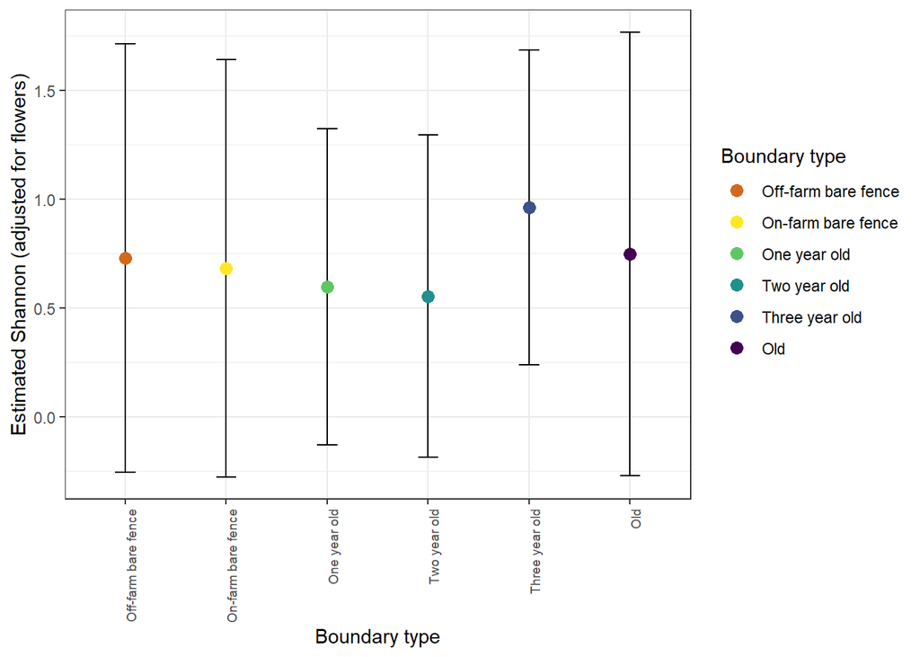

```r
cld_rich$Boundary_descriptor <- factor(cld_rich$Boundary_descriptor,levels=c('Off-farm bare fence','On-farm bare fence','One year old','Two year old','Three year old','Old'),ordered = T)

ggplot(cld_rich, aes(x = Boundary_descriptor, y = emmean)) +
#  facet_wrap(~Season)+
  theme_bw()+
  geom_errorbar(aes(ymin = lower.CL, ymax = upper.CL), width = 0.2) +
  geom_point(size = 3,aes(colour=Boundary_descriptor)) +
  scale_colour_manual(values=col_bound)+
# not sure if groupings will make sense with facet wrap
#  geom_text(aes(label = .group, y = asymp.UCL + 0.2), vjust = 0, size = 5) +
  labs(y = "Estimated Shannon (adjusted for flowers)", x = "Boundary type", colour='Boundary type') +
  theme(axis.text.x = element_text(angle = 90,size=7,hjust=1))
```

```r
#flower count as a offset
sppr_aov <-aov(simpsondiv  ~ Boundary_descriptor + Season + offset(log(`Flower count`)) , data = meta_data)
summary(sppr_aov)
```

```
##                      Df Sum Sq Mean Sq F value   Pr(>F)
## Boundary_descriptor   5  1.895  0.3790   3.399 0.006867 **
## Season                2  1.991  0.9957   8.931 0.000259 ***
## Residuals           107 11.929  0.1115
## ---
## Signif. codes:  0 '***' 0.001 '**' 0.01 '*' 0.05 '.' 0.1 ' ' 1
```

```r
TukeyHSD(sppr_aov)
```

```
##   Tukey multiple comparisons of means
##     95% family-wise confidence level
##
## Fit: aov(formula = simpsondiv ~ Boundary_descriptor + Season + offset(log(`Flower count`)), data = meta_data)
##
## $Boundary_descriptor
##                                                diff         lwr          upr
## Old-Off-farm bare fence                 0.048828435 -0.19148443  0.289141300
## On-farm bare fence-Off-farm bare fence -0.006384924 -0.26551513  0.252745287
## One year old-Off-farm bare fence        0.018066695 -0.38997839  0.426111776
## Three year old-Off-farm bare fence      0.308213450 -0.09983163  0.716258531
## Two year old-Off-farm bare fence       -0.378350826 -0.76530700  0.008605352
## On-farm bare fence-Old                 -0.055213358 -0.30046513  0.190038416
## One year old-Old                       -0.030761740 -0.43013720  0.368613717
## Three year old-Old                      0.259385015 -0.13999044  0.658760472
## Two year old-Old                       -0.427179261 -0.80498219 -0.049376335
## One year old-On-farm bare fence         0.024451619 -0.38652155  0.435424790
## Three year old-On-farm bare fence       0.314598374 -0.09637480  0.725571545
## Two year old-On-farm bare fence        -0.371965903 -0.76200852  0.018076715
## Three year old-One year old             0.290146755 -0.22778304  0.808076548
## Two year old-One year old              -0.396417521 -0.89790089  0.105065844
## Two year old-Three year old            -0.686564276 -1.18804764 -0.185080911
##                                            p adj
## Old-Off-farm bare fence                0.9915338
## On-farm bare fence-Off-farm bare fence 0.9999997
## One year old-Off-farm bare fence       0.9999950
## Three year old-Off-farm bare fence     0.2501229
## Two year old-Off-farm bare fence       0.0591983
## On-farm bare fence-Old                 0.9864785
## One year old-Old                       0.9999214
## Three year old-Old                     0.4171238
## Two year old-Old                       0.0170890
## One year old-On-farm bare fence        0.9999781
## Three year old-On-farm bare fence      0.2366692
## Two year old-On-farm bare fence        0.0707504
## Three year old-One year old            0.5835275
## Two year old-One year old              0.2056298
## Two year old-Three year old            0.0017570
##
## $Season
##                       diff         lwr         upr     p adj
## 2022/23-2021/22 -0.3004747 -0.48376058 -0.11718882 0.0004970
## 2023/24-2021/22 -0.1554555 -0.33646671  0.02555577 0.1073967
## 2023/24-2022/23  0.1450192 -0.03475049  0.32478895 0.1387459
```

## Using renyi profiles

Tracking the difference between the two communities using a renyi profile method. Dont think we can use this in the paper as I cant get season, date or farm in there for the nesting. But thought it was interesting.

The Renyi diversity profile at scale 0 reflects species richness, at scale 1 the Shannon index, at scale 2 the Simpson index and at scale Inf the Berger-Parker index (the dominance of the most abundant species):

If the profiles cross over then it may not be possible to compare diversity. I find this interesting as its the old samples that cross over. The 3 year olds don’t. This follows the above shannon/simpson analysis that shows evenness is highest in the 3-year old samples. We cant actually include this in the final paper as its not taking into account flower number/farm/date sampled like the models above are. But I wanted to get your thoughts on it as I havent seen data like this. Though the fly one was similar when simpson was so high for apple as there was basically no diversity at apple so it was perfectly even. We should probably include the accumulation plot in the supplementary though (along with the innext plots).

Im thinking that this suggests a lot more rare species are coming into the plantings compared to the bare fence. So the evenness becomes quite lower compared to the bare fence/control plantings. Which feeds into that science paper we discussed the other day about bee species rather than bee number being important.

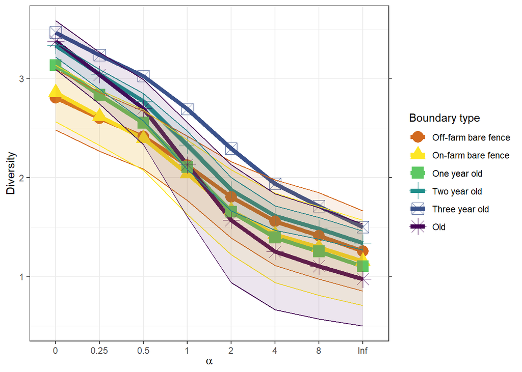

```r
meta_data$Boundary_descriptorf<-factor(meta_data$Boundary_descriptor, levels = c('Off-farm bare fence','On-farm bare fence',"One year old","Two year old","Three year old","Old"))
meta_data_bior<-as.data.frame(meta_data)
Renyi.1<-renyicomp(counts_wide,y=meta_data_bior,factor='Boundary_descriptorf',
  scales=c(0, 0.25, 0.5, 1, 2, 4, 8, Inf), permutations=1000, plotit=F)
renyi.long1 <- renyicomp.long(Renyi.1, label.freq=1)
renyi.long1_dataframe<-data.frame(renyi.long1$labelit,renyi.long1$Scales,renyi.long1$Obs,renyi.long1$Diversity,renyi.long1$UPR,renyi.long1$LWR,renyi.long1$Grouping)
renyi.long1_dataframe$Boundary_descriptor<-factor(renyi.long1_dataframe$renyi.long1.Grouping, levels = c('Off-farm bare fence','On-farm bare fence',"One year old","Two year old","Three year old","Old"))

pl_renyi_across <- ggplot(data=renyi.long1_dataframe, aes(x=renyi.long1.Scales, y=renyi.long1.Diversity, ymax=renyi.long1.UPR, ymin=renyi.long1.LWR)) +
    scale_x_discrete() +
    scale_y_continuous(sec.axis = dup_axis(labels=NULL, name=NULL)) +
    geom_line(data=renyi.long1_dataframe,
              aes(x=renyi.long1.Obs, colour=Boundary_descriptor),
              linewidth=2) +
    geom_point(data=subset(renyi.long1_dataframe, renyi.long1.labelit==TRUE),
        aes(colour=Boundary_descriptor, shape=Boundary_descriptor),
        size=5) +
    geom_ribbon(data=renyi.long1_dataframe,
                aes(x=renyi.long1.Obs, colour=Boundary_descriptor, fill=after_scale(alpha(colour, 0.1))),
                show.legend=FALSE) +
     scale_colour_manual(values=col_bound)+
    theme_bw() +
    #scale_colour_npg() +
    labs(x=expression(alpha), y = "Diversity", colour = "Boundary type", shape = "Boundary type")
pl_renyi_across
```

```r
#not great but that is conflated with the effect of season so break it up by season:
meta_data_bior_season<-meta_data_bior %>% filter(Season=='2023/24')
meta_data_bior_season %>% select(Boundary_descriptor) %>% group_by(Boundary_descriptor) %>% summarise(count = n())
```

```
## # A tibble: 6 × 2
##   Boundary_descriptor count
##   <chr>               <int>
## 1 Off-farm bare fence    11
## 2 Old                    13
## 3 On-farm bare fence      7
## 4 One year old            1
## 5 Three year old          7
## 6 Two year old            1
```

```r
counts_wide_filt <- counts_wide[rownames(counts_wide) %in% meta_data_bior_season$unique_sample, ]
counts_wide_filt <- counts_wide_filt[,colSums(counts_wide_filt) > 0]
Renyi.1<-renyicomp(counts_wide_filt,y=meta_data_bior_season,factor='Boundary_descriptorf',
  scales=c(0, 0.25, 0.5, 1, 2, 4, 8, Inf), permutations=1000, plotit=F)
```

```
## Set of permutations < 'minperm'. Generating entire set.
## Set of permutations < 'minperm'. Generating entire set.
```

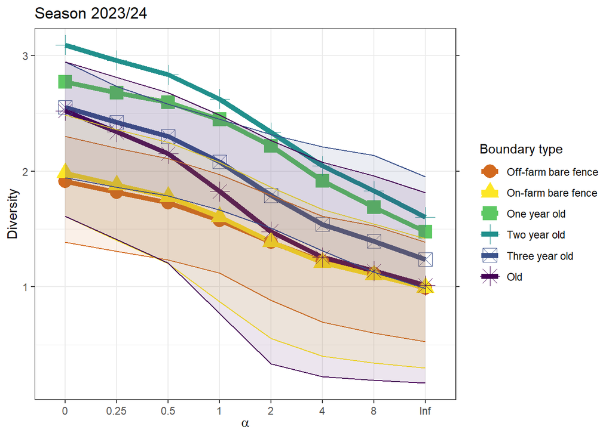

```r
renyi.long1 <- renyicomp.long(Renyi.1, label.freq=1)
renyi.long1_dataframe<-data.frame(renyi.long1$labelit,renyi.long1$Scales,renyi.long1$Obs,renyi.long1$Diversity,renyi.long1$UPR,renyi.long1$LWR,renyi.long1$Grouping)
renyi.long1_dataframe$Boundary_descriptor<-factor(renyi.long1_dataframe$renyi.long1.Grouping, levels = c('Off-farm bare fence','On-farm bare fence',"One year old","Two year old","Three year old","Old"))

pl_renyi_across <- ggplot(data=renyi.long1_dataframe, aes(x=renyi.long1.Scales, y=renyi.long1.Diversity, ymax=renyi.long1.UPR, ymin=renyi.long1.LWR)) +
    scale_x_discrete() +
    scale_y_continuous(sec.axis = dup_axis(labels=NULL, name=NULL)) +
    geom_line(data=renyi.long1_dataframe,
              aes(x=renyi.long1.Obs, colour=Boundary_descriptor),
              linewidth=2) +
    geom_point(data=subset(renyi.long1_dataframe, renyi.long1.labelit==TRUE),
        aes(colour=Boundary_descriptor, shape=Boundary_descriptor),
        size=5) +
    geom_ribbon(data=renyi.long1_dataframe,
                aes(x=renyi.long1.Obs, colour=Boundary_descriptor, fill=after_scale(alpha(colour, 0.1))),
                show.legend=FALSE) +
     scale_colour_manual(values=col_bound)+
    theme_bw() +
    labs(x=expression(alpha), y = "Diversity", colour = "Boundary type", shape = "Boundary type",title='Season 2023/24')
pl_renyi_across
```

```r
#2023/24 but also dropping the one year old and two year old that only have one replicate
meta_data_bior_season<-meta_data_bior %>% filter(Season=='2023/24') %>% filter(Boundary_descriptor!='One year old')%>% filter(Boundary_descriptor!='Two year old')
meta_data_bior_season %>% select(Boundary_descriptor) %>% group_by(Boundary_descriptor) %>% summarise(count = n())
```

```
## # A tibble: 4 × 2
##   Boundary_descriptor count
##   <chr>               <int>
## 1 Off-farm bare fence    11
## 2 Old                    13
## 3 On-farm bare fence      7
## 4 Three year old          7
```

```r
meta_data_bior_season %>% select(Boundary_descriptor) %>% group_by(Boundary_descriptor) %>% summarise(count = n())
```

```
## # A tibble: 4 × 2
##   Boundary_descriptor count
##   <chr>               <int>
## 1 Off-farm bare fence    11
## 2 Old                    13
## 3 On-farm bare fence      7
## 4 Three year old          7
```

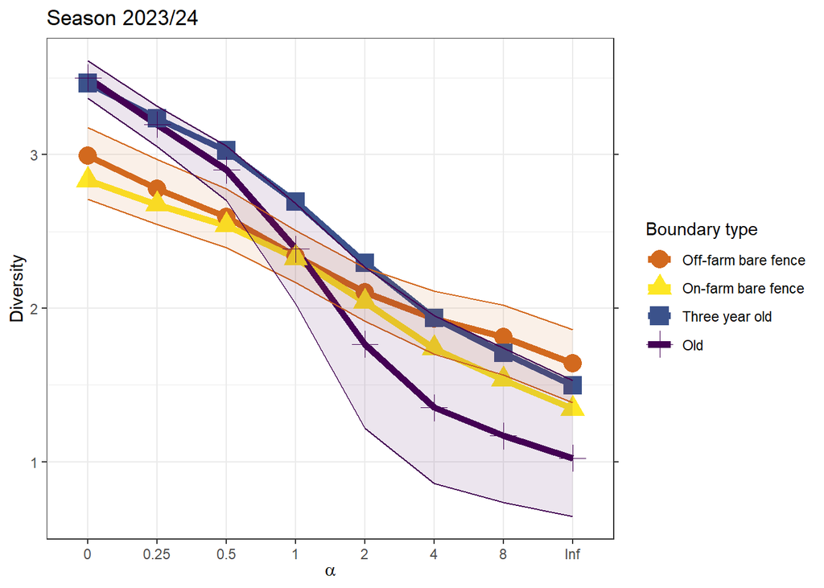

```r
meta_data_bior_season$Boundary_descriptorf<-factor(meta_data_bior_season$Boundary_descriptor, levels =c('Off-farm bare fence','On-farm bare fence',"Three year old","Old"))
counts_wide_filt <- counts_wide[rownames(counts_wide) %in% meta_data_bior_season$unique_sample, ]
counts_wide_filt <- counts_wide_filt[,colSums(counts_wide_filt) > 0]
Renyi.1<-renyicomp(counts_wide_filt,y=meta_data_bior_season,factor='Boundary_descriptorf',
  scales=c(0, 0.25, 0.5, 1, 2, 4, 8, Inf), permutations=1000, plotit=F)
renyi.long1 <- renyicomp.long(Renyi.1, label.freq=1)
renyi.long1_dataframe<-data.frame(renyi.long1$labelit,renyi.long1$Scales,renyi.long1$Obs,renyi.long1$Diversity,renyi.long1$UPR,renyi.long1$LWR,renyi.long1$Grouping)
renyi.long1_dataframe$Boundary_descriptor<-factor(renyi.long1_dataframe$renyi.long1.Grouping, levels = c('Off-farm bare fence','On-farm bare fence',"Three year old","Old"))

col_bound_cut<-c('chocolate','#FDE725FF','#3B528BFF',"#440154FF")


pl_renyi_across <- ggplot(data=renyi.long1_dataframe, aes(x=renyi.long1.Scales, y=renyi.long1.Diversity, ymax=renyi.long1.UPR, ymin=renyi.long1.LWR)) +
    scale_x_discrete() +
    scale_y_continuous(sec.axis = dup_axis(labels=NULL, name=NULL)) +
    geom_line(data=renyi.long1_dataframe,
              aes(x=renyi.long1.Obs, colour=Boundary_descriptor),
              linewidth=2) +
    geom_point(data=subset(renyi.long1_dataframe, renyi.long1.labelit==TRUE),
        aes(colour=Boundary_descriptor, shape=Boundary_descriptor),
        size=5) +
    geom_ribbon(data=renyi.long1_dataframe,
                aes(x=renyi.long1.Obs, colour=Boundary_descriptor, fill=after_scale(alpha(colour, 0.1))),
                show.legend=FALSE) +
     scale_colour_manual(values=col_bound_cut)+
    theme_bw() +
    #scale_colour_npg() +
    labs(x=expression(alpha), y = "Diversity", colour = "Boundary type", shape = "Boundary type",title='Season 2023/24')
pl_renyi_across
```

```r
#2022/23
meta_data_bior_season<-meta_data_bior %>% filter(Season=='2022/23')
meta_data_bior_season %>% select(Boundary_descriptor) %>% group_by(Boundary_descriptor) %>% summarise(count = n())
```

```
## # A tibble: 4 × 2
##   Boundary_descriptor count
##   <chr>               <int>
## 1 Off-farm bare fence     9
## 2 Old                    12
## 3 On-farm bare fence     10
## 4 Two year old            7
```

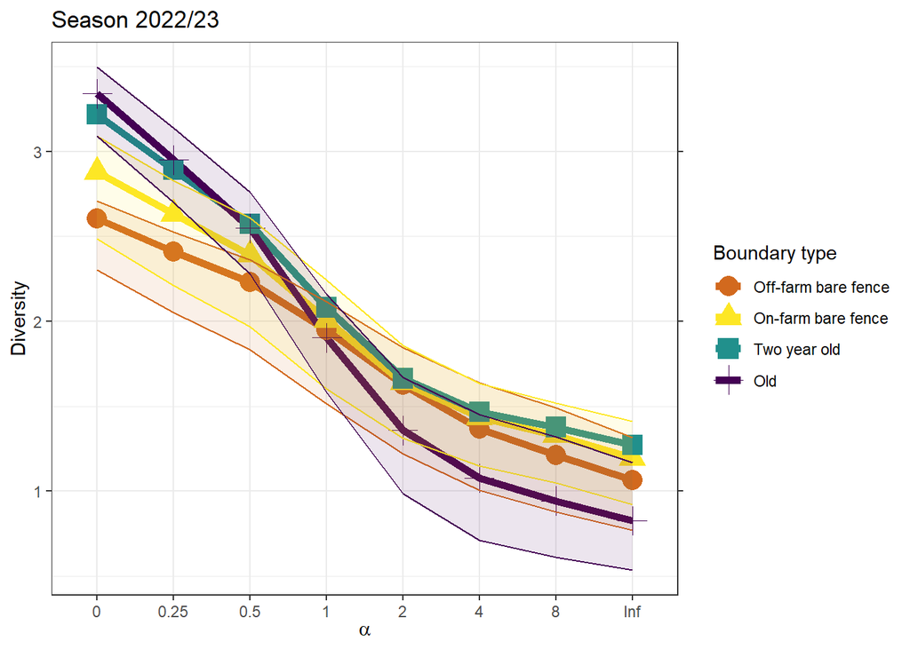

```r
meta_data_bior_season$Boundary_descriptorf<-factor(meta_data_bior_season$Boundary_descriptor, levels = c('Off-farm bare fence','On-farm bare fence',"Two year old","Old"))
counts_wide_filt <- counts_wide[rownames(counts_wide) %in% meta_data_bior_season$unique_sample, ]
counts_wide_filt <- counts_wide_filt[,colSums(counts_wide_filt) > 0]
Renyi.1<-renyicomp(counts_wide_filt,y=meta_data_bior_season,factor='Boundary_descriptorf',
  scales=c(0, 0.25, 0.5, 1, 2, 4, 8, Inf), permutations=1000, plotit=F)
renyi.long1 <- renyicomp.long(Renyi.1, label.freq=1)
renyi.long1_dataframe<-data.frame(renyi.long1$labelit,renyi.long1$Scales,renyi.long1$Obs,renyi.long1$Diversity,renyi.long1$UPR,renyi.long1$LWR,renyi.long1$Grouping)
renyi.long1_dataframe$Boundary_descriptor<-factor(renyi.long1_dataframe$renyi.long1.Grouping, levels = c('Off-farm bare fence','On-farm bare fence',"Two year old","Old"))
col_bound_cut<-c('chocolate','#FDE725FF',"#21908CFF","#440154FF")
pl_renyi_across <- ggplot(data=renyi.long1_dataframe, aes(x=renyi.long1.Scales, y=renyi.long1.Diversity, ymax=renyi.long1.UPR, ymin=renyi.long1.LWR)) +
    scale_x_discrete() +
    scale_y_continuous(sec.axis = dup_axis(labels=NULL, name=NULL)) +
    geom_line(data=renyi.long1_dataframe,
              aes(x=renyi.long1.Obs, colour=Boundary_descriptor),
              linewidth=2) +
    geom_point(data=subset(renyi.long1_dataframe, renyi.long1.labelit==TRUE),
        aes(colour=Boundary_descriptor, shape=Boundary_descriptor),
        size=5) +
    geom_ribbon(data=renyi.long1_dataframe,
                aes(x=renyi.long1.Obs, colour=Boundary_descriptor, fill=after_scale(alpha(colour, 0.1))),
                show.legend=FALSE) +
     scale_colour_manual(values=col_bound_cut)+
    theme_bw() +
    #scale_colour_npg() +
    labs(x=expression(alpha), y = "Diversity", colour = "Boundary type", shape = "Boundary type",title='Season 2022/23')
pl_renyi_across
```

```r
#2021/22
meta_data_bior_season<-meta_data_bior %>% filter(Season=='2021/22')
meta_data_bior_season %>% select(Boundary_descriptor) %>% group_by(Boundary_descriptor) %>% summarise(count = n())
```

```
## # A tibble: 4 × 2
##   Boundary_descriptor count
##   <chr>               <int>
## 1 Off-farm bare fence     9
## 2 Old                    12
## 3 On-farm bare fence     10
## 4 One year old            6
```

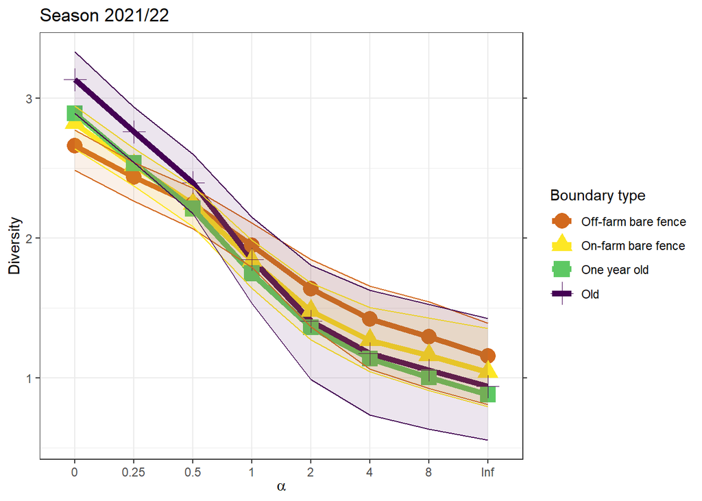

```r
meta_data_bior_season$Boundary_descriptorf<-factor(meta_data_bior_season$Boundary_descriptor, levels = c('Off-farm bare fence','On-farm bare fence',"One year old","Old"))
counts_wide_filt <- counts_wide[rownames(counts_wide) %in% meta_data_bior_season$unique_sample, ]
counts_wide_filt <- counts_wide_filt[,colSums(counts_wide_filt) > 0]
Renyi.1<-renyicomp(counts_wide_filt,y=meta_data_bior_season,factor='Boundary_descriptorf',
  scales=c(0, 0.25, 0.5, 1, 2, 4, 8, Inf), permutations=1000, plotit=F)
renyi.long1 <- renyicomp.long(Renyi.1, label.freq=1)
renyi.long1_dataframe<-data.frame(renyi.long1$labelit,renyi.long1$Scales,renyi.long1$Obs,renyi.long1$Diversity,renyi.long1$UPR,renyi.long1$LWR,renyi.long1$Grouping)
renyi.long1_dataframe$Boundary_descriptor<-factor(renyi.long1_dataframe$renyi.long1.Grouping, levels = c('Off-farm bare fence','On-farm bare fence',"One year old","Old"))
col_bound_cut<-c('chocolate','#FDE725FF',"#5DC863FF","#440154FF")

pl_renyi_across <- ggplot(data=renyi.long1_dataframe, aes(x=renyi.long1.Scales, y=renyi.long1.Diversity, ymax=renyi.long1.UPR, ymin=renyi.long1.LWR)) +
    scale_x_discrete() +
    scale_y_continuous(sec.axis = dup_axis(labels=NULL, name=NULL)) +
    geom_line(data=renyi.long1_dataframe,
              aes(x=renyi.long1.Obs, colour=Boundary_descriptor),
              linewidth=2) +
    geom_point(data=subset(renyi.long1_dataframe, renyi.long1.labelit==TRUE),
        aes(colour=Boundary_descriptor, shape=Boundary_descriptor),
        size=5) +
    geom_ribbon(data=renyi.long1_dataframe,
                aes(x=renyi.long1.Obs, colour=Boundary_descriptor, fill=after_scale(alpha(colour, 0.1))),
                show.legend=FALSE) +
     scale_colour_manual(values=col_bound_cut)+
    theme_bw() +
    #scale_colour_npg() +
    labs(x=expression(alpha), y = "Diversity", colour = "Boundary type", shape = "Boundary type",title='Season 2021/22')
pl_renyi_across
```

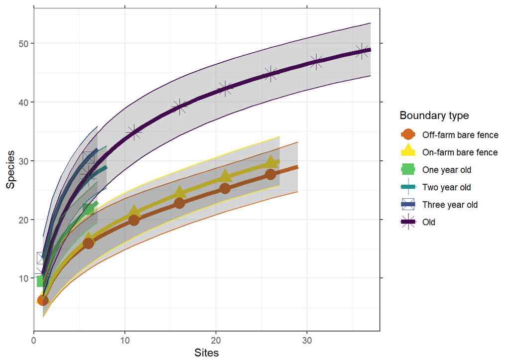

```r
#hmmm pattern holds across seasons, I thought maybe that it would be one season throwing everyone out

#just having a look at the accum results:
Accum.1 <- accumcomp(counts_wide,y=meta_data_bior,factor='Boundary_descriptorf',
    method='exact', conditioned=FALSE, plotit=FALSE)
accum.long1 <- accumcomp.long(Accum.1, ci=NA, label.freq=5)
accum.long1_dataframe<-data.frame(accum.long1$Grouping,accum.long1$Obs,accum.long1$Sites,accum.long1$Richness,accum.long1$LWR,accum.long1$UPR,accum.long1$labelit)
accum.long1_dataframe$Boundary_descriptor<-factor(accum.long1_dataframe$accum.long1.Grouping, levels = c('Off-farm bare fence','On-farm bare fence',"One year old","Two year old","Three year old","Old"))


plotgg1 <- ggplot(data=accum.long1_dataframe, aes(x = accum.long1.Sites, y = accum.long1.Richness, ymax = accum.long1.UPR, ymin = accum.long1.LWR)) +
    scale_x_continuous(expand=c(0, 1), sec.axis = dup_axis(labels=NULL, name=NULL)) +
    scale_y_continuous(sec.axis = dup_axis(labels=NULL, name=NULL)) +
    geom_line(aes(colour=Boundary_descriptor), linewidth=2) +
    geom_point(data=subset(accum.long1_dataframe, accum.long1.labelit==TRUE),
               aes(colour=Boundary_descriptor, shape=Boundary_descriptor), size=5) +
    geom_ribbon(aes(colour=Boundary_descriptor), alpha=0.2, show.legend=FALSE) +
     scale_colour_manual(values=col_bound)+
    theme_bw() +
    labs(x = "Sites", y = "Species", colour = "Boundary type", shape = "Boundary type")
plotgg1
```

```r
#
```

## Beta Diversity

Beta diversity analysis Adonis2 works with nesting via a strata factor that blocks permutations to within groups however if you add both Date and Farm it doesnt have enough space to shuffle things around within the groups.

This analysis is important but Im finding it the most difficult as it makes a large difference how I structure the data (the other ones it doesnt matter what I do the answer is the same). In the other diversity tests, it really doesnt make much difference to the overall result but here it does.

```r
#beta diversity
#cant run an offset in adonis so flower count going in as a variable
perm<-adonis2(counts_wide ~ Boundary_descriptor + `Flower count`+Season, data = meta_data)
perm
```

```
## Permutation test for adonis under reduced model
## Permutation: free
## Number of permutations: 999
##
## adonis2(formula = counts_wide ~ Boundary_descriptor + `Flower count` + Season, data = meta_data)
##           Df SumOfSqs     R2      F Pr(>F)
## Model      8    5.659 0.1966 3.2424  0.001 ***
## Residual 106   23.125 0.8034
## Total    114   28.784 1.0000
## ---
## Signif. codes:  0 '***' 0.001 '**' 0.01 '*' 0.05 '.' 0.1 ' ' 1
```

```r
#we need to restrict permutations around nesting:
####################################
#so if site and date were irreverent I could just do
#strata for season
perm<-adonis2(counts_wide ~ Boundary_descriptor + `Flower count`, data = meta_data, strata = meta_data$Season)
perm
```

```
## Permutation test for adonis under reduced model
## Blocks:  strata
## Permutation: free
## Number of permutations: 999
##
## adonis2(formula = counts_wide ~ Boundary_descriptor + `Flower count`, data = meta_data, strata = meta_data$Season)
##           Df SumOfSqs      R2      F Pr(>F)
## Model      6   3.6673 0.12741 2.6282  0.001 ***
## Residual 108  25.1170 0.87259
## Total    114  28.7843 1.00000
## ---
## Signif. codes:  0 '***' 0.001 '**' 0.01 '*' 0.05 '.' 0.1 ' ' 1
```

```r
pairwise_adonis<-pairwise.adonis2(counts_wide ~ Boundary_descriptor + `Flower count`,data=meta_data_bior,strata='Season')
pairwise_adonis
```

```
## $parent_call
## [1] "counts_wide ~ Boundary_descriptor + `Flower count` , strata = Season , permutations 999"
##
## $`Off-farm bare fence_vs_One year old`
##          Df SumOfSqs      R2      F Pr(>F)
## Model     2   1.0454 0.10636 1.9638  0.038 *
## Residual 33   8.7838 0.89364
## Total    35   9.8292 1.00000
## ---
## Signif. codes:  0 '***' 0.001 '**' 0.01 '*' 0.05 '.' 0.1 ' ' 1
##
## $`Off-farm bare fence_vs_Two year old`
##          Df SumOfSqs      R2     F Pr(>F)
## Model     2   0.8740 0.08803 1.641  0.038 *
## Residual 34   9.0537 0.91197
## Total    36   9.9276 1.00000
## ---
## Signif. codes:  0 '***' 0.001 '**' 0.01 '*' 0.05 '.' 0.1 ' ' 1
##
## $`Off-farm bare fence_vs_Three year old`
##          Df SumOfSqs      R2      F Pr(>F)
## Model     2   0.8502 0.08939 1.6197  0.066 .
## Residual 33   8.6612 0.91061
## Total    35   9.5114 1.00000
## ---
## Signif. codes:  0 '***' 0.001 '**' 0.01 '*' 0.05 '.' 0.1 ' ' 1
##
## $`Off-farm bare fence_vs_Old`
##          Df SumOfSqs      R2      F Pr(>F)
## Model     2   1.7862 0.11036 3.9077  0.001 ***
## Residual 63  14.3983 0.88964
## Total    65  16.1845 1.00000
## ---
## Signif. codes:  0 '***' 0.001 '**' 0.01 '*' 0.05 '.' 0.1 ' ' 1
##
## $`Off-farm bare fence_vs_On-farm bare fence`
##          Df SumOfSqs      R2      F Pr(>F)
## Model     2   0.6315 0.04384 1.2149  0.246
## Residual 53  13.7734 0.95616
## Total    55  14.4048 1.00000
```

[output cut: 62 more lines]

```
##          Df SumOfSqs      R2      F Pr(>F)
## Model     2   0.9082 0.10835 1.8835  0.146
## Residual 31   7.4744 0.89165
## Total    33   8.3826 1.00000
##
## $`Old_vs_On-farm bare fence`
##          Df SumOfSqs      R2      F Pr(>F)
## Model     2   1.5673 0.10603 3.6173  0.001 ***
## Residual 61  13.2151 0.89397
## Total    63  14.7824 1.00000
## ---
## Signif. codes:  0 '***' 0.001 '**' 0.01 '*' 0.05 '.' 0.1 ' ' 1
##
## attr(,"class")
## [1] "pwadstrata" "list"
```

```r
#but you know not in my ideal world and I cant work out the best way to get both date and farm in.
#adonis can only take one strata value so either combine into one
#season farm and month split
meta_data$site_day_seas <- interaction(meta_data$Farm_name, meta_data$month_split,meta_data$Season, drop = TRUE)
perm<-adonis2(counts_wide ~ Boundary_descriptor +`Flower count`, data = meta_data, strata = meta_data$site_day_seas)
perm
```

```
## Permutation test for adonis under reduced model
## Blocks:  strata
## Permutation: free
## Number of permutations: 999
##
## adonis2(formula = counts_wide ~ Boundary_descriptor + `Flower count`, data = meta_data, strata = meta_data$site_day_seas)
##           Df SumOfSqs      R2      F Pr(>F)
## Model      6   3.6673 0.12741 2.6282  0.001 ***
## Residual 108  25.1170 0.87259
## Total    114  28.7843 1.00000
## ---
## Signif. codes:  0 '***' 0.001 '**' 0.01 '*' 0.05 '.' 0.1 ' ' 1
```

```r
#so we can say there is a significant impact of boundary

#but the pairwise adhoc afterwards doesnt work as their is no movement for strata between groups
#so dropping back to season and month
meta_data_bior$month_season <- interaction(meta_data_bior$Collection_month, meta_data_bior$Season, drop = TRUE)
pairwise_adonis<-NULL
pairwise_adonis<-pairwise.adonis2(counts_wide ~ Boundary_descriptor +`Flower count`,data=meta_data_bior, strata='month_season')
pairwise_adonis
```

```
## $parent_call
## [1] "counts_wide ~ Boundary_descriptor + `Flower count` , strata = month_season , permutations 999"
##
## $`Off-farm bare fence_vs_One year old`
##          Df SumOfSqs      R2      F Pr(>F)
## Model     2   1.0454 0.10636 1.9638  0.122
## Residual 33   8.7838 0.89364
## Total    35   9.8292 1.00000
##
## $`Off-farm bare fence_vs_Two year old`
##          Df SumOfSqs      R2     F Pr(>F)
## Model     2   0.8740 0.08803 1.641  0.004 **
## Residual 34   9.0537 0.91197
## Total    36   9.9276 1.00000
## ---
## Signif. codes:  0 '***' 0.001 '**' 0.01 '*' 0.05 '.' 0.1 ' ' 1
##
## $`Off-farm bare fence_vs_Three year old`
##          Df SumOfSqs      R2      F Pr(>F)
## Model     2   0.8502 0.08939 1.6197  0.015 *
## Residual 33   8.6612 0.91061
## Total    35   9.5114 1.00000
## ---
## Signif. codes:  0 '***' 0.001 '**' 0.01 '*' 0.05 '.' 0.1 ' ' 1
##
## $`Off-farm bare fence_vs_Old`
##          Df SumOfSqs      R2      F Pr(>F)
## Model     2   1.7862 0.11036 3.9077  0.001 ***
## Residual 63  14.3983 0.88964
## Total    65  16.1845 1.00000
## ---
## Signif. codes:  0 '***' 0.001 '**' 0.01 '*' 0.05 '.' 0.1 ' ' 1
##
## $`Off-farm bare fence_vs_On-farm bare fence`
##          Df SumOfSqs      R2      F Pr(>F)
## Model     2   0.6315 0.04384 1.2149   0.16
## Residual 53  13.7734 0.95616
## Total    55  14.4048 1.00000
##
## $`One year old_vs_Two year old`
```

[output cut: 58 more lines]

```
##          Df SumOfSqs      R2      F Pr(>F)
## Model     2   0.9082 0.10835 1.8835  0.127
## Residual 31   7.4744 0.89165
## Total    33   8.3826 1.00000
##
## $`Old_vs_On-farm bare fence`
##          Df SumOfSqs      R2      F Pr(>F)
## Model     2   1.5673 0.10603 3.6173  0.001 ***
## Residual 61  13.2151 0.89397
## Total    63  14.7824 1.00000
## ---
## Signif. codes:  0 '***' 0.001 '**' 0.01 '*' 0.05 '.' 0.1 ' ' 1
##
## attr(,"class")
## [1] "pwadstrata" "list"
```

```r
#if I wanted to include farm Im not sure that I can with season, there is too many that are singles
#I've tried every permutation and there just isnt enough freedom in the strata system to get those in
#season has by far the biggest impact so season/month is the best we can do maybe?
```

## NMDS

NMDS plot

```r
#NMDS is struggling to find a repeated solution. I think this is due to the rare species
#https://stats.stackexchange.com/questions/649643/best-solution-was-not-repeated-no-reliable-result-for-metamds

pk_NMDS <- metaMDS(counts_wide,trymax=200,distance='bray')
```

```
## Square root transformation
## Wisconsin double standardization
## *** Best solution repeated 1 times
```

```r
pk_NMDS
```

```
##
## Call:
## metaMDS(comm = counts_wide, distance = "bray", trymax = 200)
##
## global Multidimensional Scaling using monoMDS
##
## Data:     wisconsin(sqrt(counts_wide))
## Distance: bray
##
## Dimensions: 2
## Stress:     0.2624369
## Stress type 1, weak ties
## Best solution was repeated 1 time in 29 tries
## The best solution was from try 29 (random start)
## Scaling: centring, PC rotation, halfchange scaling
## Species: expanded scores based on 'wisconsin(sqrt(counts_wide))'
```

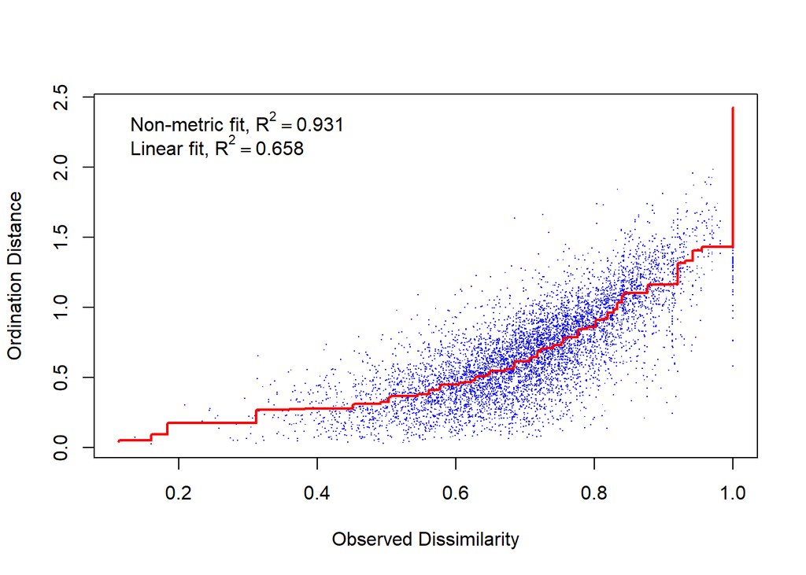

```r
#stress is a little high (ideally <0.2)

stressplot(pk_NMDS)
```

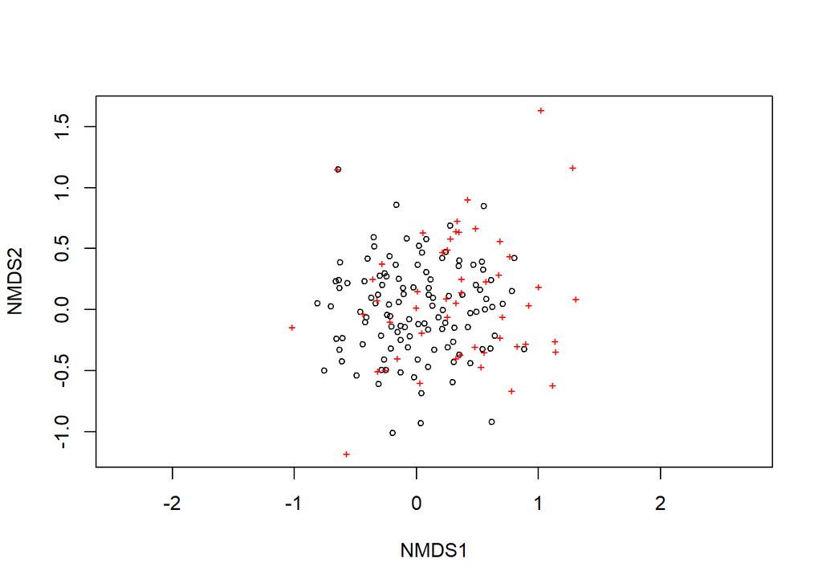

```r
plot(pk_NMDS)
```

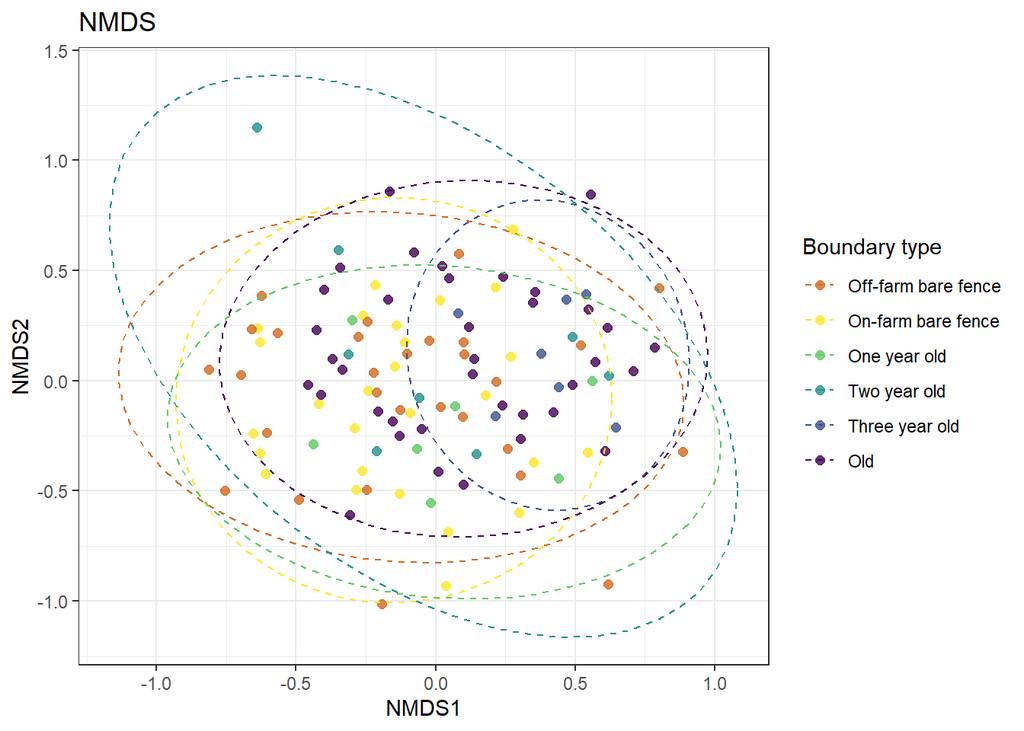

```r
plot_df <- scores(pk_NMDS, display = "sites") %>%
  as.data.frame() %>%
  rownames_to_column("site") %>%
  full_join(meta_data, by = c("site" = "unique_sample"))

plot_df$Boundary_descriptor <- factor(plot_df$Boundary_descriptor,levels=c('Off-farm bare fence','On-farm bare fence','One year old','Two year old','Three year old','Old'),ordered = T)


plot_nmds <- ggplot(plot_df, aes(x = NMDS1, y = NMDS2, color = Boundary_descriptor)) +
  geom_point(size = 2, alpha = 0.8) +
  stat_ellipse(linetype = 2, linewidth = 0.5) +
  theme_bw()+
    scale_colour_manual(values=col_bound)+
  labs(title = "NMDS",
       colour = "Boundary type")
plot_nmds
```

## RDA

An alternative to the MDS that would align well with the adonis2 beta diversity analysis would be a rda (constrained PCA - PCA on predicted variables) and using the model. For the species lines note that I double the length here for plotting

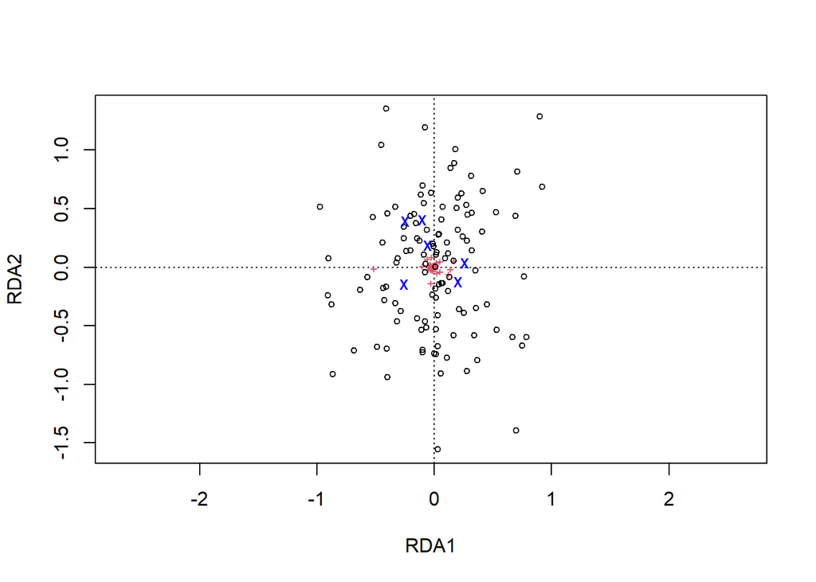

```r
counts_wide.Hellinger <- disttransform(counts_wide, method='hellinger')
#add conditions here for random effects:
Ordination.model2 <- rda(counts_wide.Hellinger ~ Boundary_descriptorf +  offset(log(`Flower count`)) + Condition(Season)+Condition(Farm_name)+Condition(month_split), data=meta_data_bior, scaling="species")

plot2 <- ordiplot(Ordination.model2, choices=c(1,2))
```

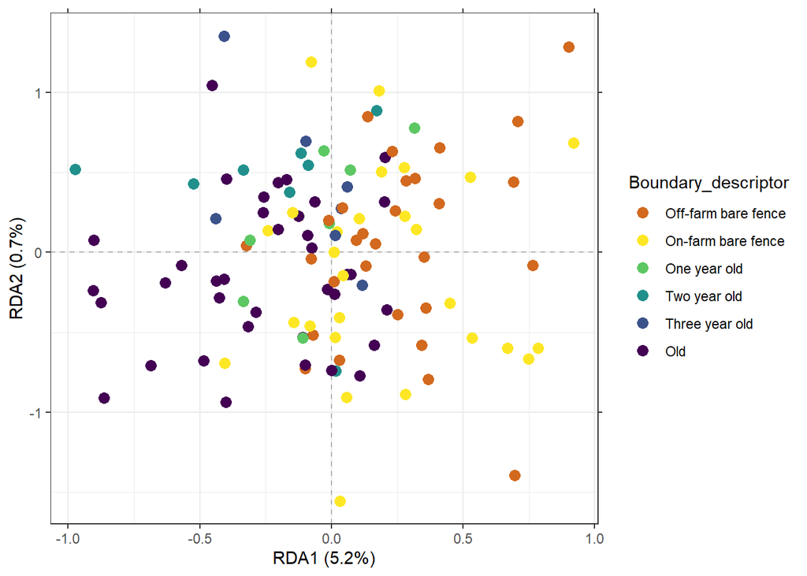

```r
sites.long2 <- sites.long(plot2, env.data=meta_data_bior)
species.long2 <- species.long(plot2)
axis.long2 <- axis.long(Ordination.model2, choices=c(1, 2))
sites.long2$Boundary_descriptor <- factor(sites.long2$Boundary_descriptor,levels=c('Off-farm bare fence','On-farm bare fence','One year old','Two year old','Three year old','Old'),ordered = T)

#just dots
plotgg2 <- ggplot() +
    geom_vline(xintercept = c(0), color = "grey70", linetype = 2) +
    geom_hline(yintercept = c(0), color = "grey70", linetype = 2) +
    xlab(axis.long2[1, "label"]) +
    ylab(axis.long2[2, "label"]) +
    scale_x_continuous(sec.axis = dup_axis(labels=NULL, name=NULL)) +
    scale_y_continuous(sec.axis = dup_axis(labels=NULL, name=NULL)) +
    geom_point(data=sites.long2,
               aes(x=axis1, y=axis2, colour=Boundary_descriptor),
               size=3) +
   scale_colour_manual(values=col_bound)+
    theme_bw()

plotgg2
```

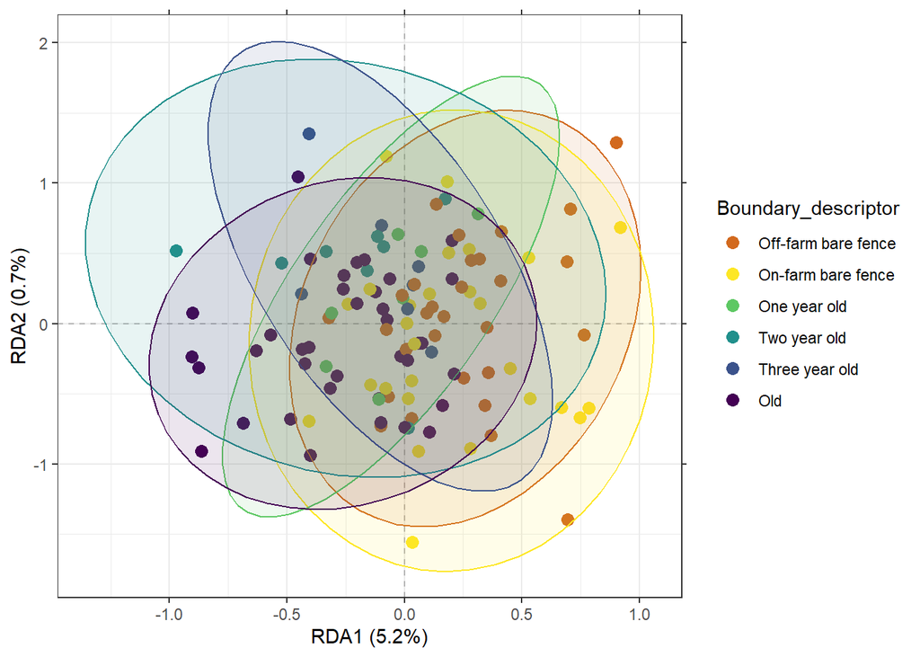

```r
#95% circles
plotgg2 <- ggplot() +
    geom_vline(xintercept = c(0), color = "grey70", linetype = 2) +
    geom_hline(yintercept = c(0), color = "grey70", linetype = 2) +
    xlab(axis.long2[1, "label"]) +
    ylab(axis.long2[2, "label"]) +
    scale_x_continuous(sec.axis = dup_axis(labels=NULL, name=NULL)) +
    scale_y_continuous(sec.axis = dup_axis(labels=NULL, name=NULL)) +
    geom_point(data=sites.long2,
               aes(x=axis1, y=axis2, colour=Boundary_descriptor),
               size=3) +
  stat_ellipse(data=sites.long2,
                      aes(x=axis1, y=axis2, colour=Boundary_descriptor, fill=Boundary_descriptor),
type='norm',level=0.95,geom='polygon',alpha=0.1,show.legend=F) +
    scale_colour_manual(values=col_bound)+
     scale_fill_manual(values=col_bound)+
   theme_bw()

plotgg2
```